# 4-Manifolds

# 36 Friday, April 09

Recall the adjunction formula: for $D \subset X \in {\mathsf{Mfd}}_{\mathbb{C}}$ a codimension 1 complex submanifold, we have
$$\begin{align*}
K_D = (K_x + {\mathcal{O}}_x(0)) { \left.{{}} \right|_{{D}} }
.\end{align*}
We’ll apply this to curves \(C\) in a surface \(S\). Recall the genus formula, which was given by \(2g(C) - 2= (C+ K_S)\cdot C\). For example, a degree 4 equation in \({\mathbb{P}}^2\) carves out a genus \(g(C) = 3\) complex curve.$$

Recall that line bundles on ${\mathbb{CP}}^n$ were in bijection with ${\mathbb{Z}}$, where send $d$ to a bundle ${\mathcal{O}}(d) \mathrel{\vcenter{:}}={\mathcal{O}}_{{\mathbb{CP}}^N}(d)$. We produced the tautological line bundle ${\mathcal{O}}(-1)$ whose fiber over $\mathbf{x} \subseteq {\mathbb{CP}}^n$ is the line in ${\mathbb{C}}^n$ spanned by its coordinates. We have ${\mathcal{O}}(-1) {}^{ \vee }\mathrel{\vcenter{:}}={\mathcal{O}}(1)$, and ${\mathcal{O}}(n)\mathrel{\vcenter{:}}={\mathcal{O}}(1)^{\otimes n}$. Alternatively, it was characterized in terms of homogeneous functions, where the fiber ${\mathcal{O}}(n)_{\mathbf{x}}$ are the linear functions $L$ on lines $\left\{{\lambda \mathbf{x}}\right\} \to {\mathbb{C}}$ such that $L(\lambda p) = \lambda^n L(p)$. Noting that these are linear functions, such $L$ form a 1-dimensional ${\mathbb{C}}{\hbox{-}}$vector space.

The classic example is $x_0 \in {\mathcal{O}}(1)_{\mathbf{x}}$ since $x_0( \lambda p) = \lambda x_0 (p)$. Similarly, $x_0^2 + x_1 x_2 \in {\mathcal{O}}(2)_{\mathbf{x}}$ since
$$\begin{align*}
x_0^2 + x_1 x_2 (\lambda p) = \lambda^2 (x_0^2 + x_1 x_2(p))
.\end{align*}$$

Note that the global sections were given by $\Gamma^0({\mathbb{P}}^n, {\mathcal{O}}(d)) = H^0({\mathbb{P}}^n; {\mathcal{O}}(d))$ was the span of degree $d$ monomials in $x_0, \cdots, x_n$. For example $x_0^2 + x_1 x_2$ is a well-defined element of ${\mathcal{O}}(2)_p$ which varies holomorphically with $p$, yielding a section:

[figure not shown]

For a K3 surface, consider $S = \left\{{ \sum_{i=0}^4 x_i^4 = 0 }\right\} \subset {\mathbb{CP}}^3$. By the adjunction formula,
$$\begin{align*}
K_S = { \left.{{\qty{ K_{{\mathbb{CP}}^3} \otimes{\mathcal{O}}_{{\mathbb{CP}}^3}(S) }}} \right|_{{S}} }
.\end{align*}
Note that if \(s\in H^0(\mathcal{L})\), we can recover \({\mathcal{O}}(\operatorname{Div}S) = \mathcal{L}\). Moreover, \(K_{{\mathbb{CP}}^3} = {\mathcal{O}}(-4)\) and \({\mathcal{O}}_{{\mathbb{CP}}^3}(S) = {\mathcal{O}}(4)\) since we can view the formula as a function on the tautological line, which yields a section. So we get \(K_S = {\mathcal{O}}(-4) \otimes{\mathcal{O}}(4) = {\mathcal{O}}(0) = {\mathcal{O}}\), i.e. these yield actual functions on \({\mathbb{CP}}^n\) since they’re products of functions that scale by \(\lambda^{-4}\) and functions that scale by \(\lambda^4\). We’re using the fact that \({\mathcal{O}}_{\mathbf{p} = [x_0: \cdots : x_n]}\) are functions \(L\) such that \(L(\lambda p) = \lambda^0 L(p) = L(p)\), which yields a well-defined function on \({\mathbb{CP}}^n\). So quartics in \({\mathbb{P}}^3\) have trivial canonical bundle, i.e. \(K_S = {\mathcal{O}}_S\) for \(S = V(x_0^4 + x_1^4 + x_2^4 + x_3^4)\).$$

We know that $H^0(S, K_S)$ are the globally holomorphic 2-forms on $S$, and here this is isomorphic to $H^0(S, {\mathcal{O}}_S) = {\mathbb{C}}\Omega_S$ for some single holomorphic 2-form. Moreover $\operatorname{Div}(\Omega_S) = 0$ since ${\mathcal{O}}( \operatorname{Div}( \Omega_S)) = K_S = {\mathcal{O}}_S$. So these are the analogs of elliptic curves in dimension 2, since for example $E \mathrel{\vcenter{:}}={\mathbb{C}}/ \Lambda$ has a nonvanishing section $\,dz\in H^0(E, K_E)$, and we can write $E = V(f)$ for $f$ a cubic in ${\mathbb{P}}^3$, and we computed the genus of cubics. Moreover, every genus 1 curve is ${\mathbb{C}}$ mod a lattice.

Recall an exercise from the notes: computing the Hodge diamond of a genus 5 curve. We’ll compute the diamond for a K3 surface:

[figure not shown]

We know $h^{2, 0} = H^0( S, \Omega_S^2)$, which yields 1s:

[figure not shown]

> [Link to Diagram](https://q.uiver.app/?q=WzAsOSxbMiwwLCIxIl0sWzEsMSwiaF57MywgMX0iXSxbMywxLCJoXnsxLCAzfSJdLFswLDIsIjEiXSxbMiwyLCJoXnsxLCAxfSJdLFs0LDIsIjEiXSxbMSwzLCJoXnsxLCAwfSJdLFszLDMsImheezAsIDF9Il0sWzIsNCwiMSJdXQ==)

We’ll use the following theorem:

Let $X \subset {\mathbb{P}}^n$ with $\dim X > 3$. Then $\pi_1(X) \cong \pi_1(X \cap H)$ for $H$ a hypersurface intersection $X$ at a smooth codimension 1 complex manifold.

Applying this to $X = {\mathbb{P}}^3$, we have $V(x_0^4 + \cdots + x_3^4) = S$, we have $\pi_1({\mathbb{P}}^3) = \pi_1(S)$. We can write ${\mathbb{P}}^3 = {\mathbb{C}}\cup{\mathbb{C}}^2 \cup{\mathbb{C}}^4$, which is a cell decomposition with cells only in degrees 0,2,4, and so in fact $\pi_1({\mathbb{P}}^n) = 0$.

K3 surfaces are simply connected, and $h^1(S; {\mathbb{C}}) = 0$.

Note that anything embedded in projective space as a complex submanifold is Kähler by restricting the Fubini-Study form. Using simple connectedness and Serre duality, we have

[figure not shown]

> [Link to Diagram](https://q.uiver.app/?q=WzAsOSxbMiwwLCIxIl0sWzEsMSwiMCJdLFszLDEsIjAiXSxbMCwyLCIxIl0sWzIsMiwiaF57MSwgMX0iXSxbNCwyLCIxIl0sWzEsMywiMCJdLFszLDMsIjAiXSxbMiw0LCIxIl1d)

We know $\chi({\mathcal{O}}_S) = (1/12)(K^2+\chi_{\mathsf{Top}})$, and since $K_S = {\mathcal{O}}_S$ is trivial, we have $c_1({\mathcal{O}}_S) = 0$. Noting that $h^{p, q} = H^( \Omega^p)$, so we can sum the lower-right part of the diamond to get $\chi({\mathcal{O}}_S) = 1 - 0 + 1 = 2$, since we take $p=0$ to get $\Omega^p = {\mathcal{O}}$. Computing $\chi_{\mathsf{Top}}$, we get $h_{1, 1} = 20$.

# 37 Monday, April 12

Last time: the Lefschetz hyperplane theorem. Intersecting a projective variety of dimension $d\geq 3$ with a hypersurface $S$, the map $\pi_1({\mathbb{P}}^3) \to \pi_1(S)$ is an isomorphism. We saw that K3 surfaces were thus simply connected, and $h^1(S; {\mathbb{C}}) = 0$, so we could compute the Hodge diamond.

What is the Hodge diamond for a cubic surface $S \subseteq {\mathbb{P}}^3$, such as $\sum x_i^3 = 0$? We first need to compute the canonical bundle $K$, for which we have a useful tool: the adjunction formula. This say $K_S = \qty{K_{{\mathbb{P}}^3} \otimes{\mathbb{P}}_{{\mathbb{P}}^3}(S) } { \left.{{}} \right|_{{S}} } = \qty{ {\mathcal{O}}(-4) \otimes{\mathcal{O}}(3) }{ \left.{{}} \right|_{{S}} } = { \left.{{ {\mathcal{O}}(-1)}} \right|_{{S}} }$.

Let $\mathcal{L} \to X$ be a holomorphic line bundle. If $h^0( \mathcal{L} ^{-1}) > 0$, then either $\mathcal{L} = {\mathcal{O}}$ or $h^0(\mathcal{L}) = 0$.

If a line bundle has a section, its inverse does not.

Suppose that both $\mathcal{L}, \mathcal{L}^{-1}$ have a section, so $h^0(\mathcal{L}), h^0( \mathcal{L} ) > 0$. Let $s, t$ be sections of each, then $st\in H^0( \mathcal{L} \otimes\mathcal{L}^{-1}) = H^0({\mathcal{O}}) = {\mathbb{C}}$. So taking zero loci yields $\operatorname{Div}(s) + \operatorname{Div}(t) = 0$ Writing these as $\operatorname{Div}(s) \mathrel{\vcenter{:}}=\sum n_D D, \operatorname{Div}(t) \mathrel{\vcenter{:}}=\sum n_C C$, we have $n_D, n_C \geq 0$, which implies that $\operatorname{Div}(s) = \operatorname{Div}(t) = 0$. So $s, t$ are nowhere vanishing, making ${\mathcal{O}}\xrightarrow{\cdot s} \mathcal{L}$ is an isomorphism.

For $S$ a cubic surface, $H^0(S; K_S) = 0$.

This follows because $K_S = {\mathcal{O}}_S(-1)$, so $K_S^{-1}= {\mathcal{O}}_S(1)$ which has a nontrivial section: namely ${\mathcal{O}}_{{\mathbb{CP}}^1}(1)$ which has sections vanishing along hyperplanes.

[figure not shown]

Letting $H$ be a hyperplane containing $S$, there exists an $f\in H^0({\mathbb{P}}^3; {\mathcal{O}}_{{\mathbb{CP}}^3}(1))$. Since $\operatorname{Div}(f) = H$, the restriction ${ \left.{{f}} \right|_{{S}} }$ is a section of ${\mathcal{O}}_S(-1) = K_S^{-1}$ which is not identically zero and vanishes along $H \cap S$.

We now know $h^0(S; K_S) = 0$, and this equals $h^0(S, \Omega^2) = h^{2, 0}(S)$, so we have the following Hodge diamond:

[figure not shown]

> [Link to Diagram](https://q.uiver.app/?q=WzAsOSxbMiwwLCIxIl0sWzEsMSwiMCJdLFszLDEsIjAiXSxbMCwyLCIwIl0sWzIsMiwiaF57MSwgMX0iXSxbNCwyLCIwIl0sWzEsMywiMCJdLFszLDMsIjAiXSxbMiw0LCIxIl1d)

Take $H_1 \mathrel{\vcenter{:}}=\left\{{ x_0 = 0 }\right\}$ and $H_2 \mathrel{\vcenter{:}}=\left\{{ x_1 = 0 }\right\}$. Points in this intersection are of the form $[0:0:1:\zeta_6^a]$ where $a=1,3,5$ since this is in the triple intersection $H_1 \cap H_2 \cap S$. So there are exactly 3 points here, and in fact $\deg S =3$. This is the same as integrating $\int_{{\mathbb{P}}^3} c_1(S) c_1( {\mathcal{O}}(1)) c_1( {\mathcal{O}}(2))$, which contains 3 elements in $H^2$ and lands in $H^6$, so this yields a number.

We thus have $K_S = {\mathcal{O}}_S(-1) \mathrel{\vcenter{:}}={\mathcal{O}}_{{\mathbb{CP}}^3}(-1) { \left.{{}} \right|_{{S}} }$. Thus $\chi_{\mathsf{Top}}(S) = 9$ and $h^{1, 1} = 7$.

Note that a degree 5 surface (a quintic) such as $x_0^5 + x_3^5 = 0$ would be harder, since $h^{2, 0} \neq 0$. We would get $K_S = {\mathcal{O}}(-4) \otimes{\mathcal{O}}(5) { \left.{{}} \right|_{{S}} } = {\mathcal{O}}_S(1)$, and there are nontrivial sections so $h^0(K_S) = {\operatorname{span}}{x_0, x_1, x_2, x_3}$. This follows because there is a map given by restriction which turns out to be an isomorphism
$$\begin{align*}
0 \to H^0({\mathbb{P}}^3; {\mathcal{O}}(1)) & \xrightarrow{\mathop{\mathrm{res}}_S} H^0(S; {\mathcal{O}}(1)) \to 0 \\
f &\mapsto { \left.{{f}} \right|_{{S}} }
.\end{align*}$$

Injectivity isn’t difficult, surjectivity is harder. We have a SES
$$\begin{align*}
0 \to {\mathcal{O}}_{{\mathbb{CP}}^3}(-S) \to {\mathcal{O}}_{{\mathbb{CP}}^3} \to {\mathcal{O}}_S \to 0
.\end{align*}
Tensor all of these with \({\mathcal{O}}(1)\) to obtain
\begin{align*}
0 \to {\mathcal{O}}_{\mathbb{CP}}^3(-4) \to {\mathcal{O}}_{{\mathbb{CP}}^3}(1) \to {\mathcal{O}}_S(1) \to 0
.\end{align*}
Taking the associated LES yields$$

[figure not shown]

> Link to Diagram

This gives us a way to relate things back to the cohomology of ${\mathbb{CP}}^3$. Showing that the indicated term is zero involves computing Čech cohomology.

It turns out that $h^0(K_S) = 4$ here, and it turns out that the Hodge diamond is the following:

[figure not shown]

> [Link to Diagram](https://q.uiver.app/?q=WzAsOSxbMiwwLCIxIl0sWzEsMSwiMCJdLFszLDEsIjAiXSxbMCwyLCI0Il0sWzQsMiwiNCJdLFsxLDMsIjAiXSxbMywzLCIwIl0sWzIsNCwiMSJdLFsyLDIsImheezEsIDF9ID0gNDUiXV0=)

Here $K_S^2 = c_1({\mathcal{O}}_S(1))^2 = 5$ and $\chi_{\mathsf{Top}}= 55$.

Consider now a product of curves $C \times D$ of genera $g, h$ respectively. Computing the Hodge diamond is easy here due to the Kunneth formula:
$$\begin{align*}
H^k(S; {\mathbb{C}}) = \bigoplus_{i+j = k} H^i(C; {\mathbb{C}}) \otimes H^j(D; {\mathbb{C}})
.\end{align*}$$

What is the actual map? Take cohomology classes $[\alpha], [\beta]$, closed $i$ and $j$ forms respectively. The surface has two maps:

[figure not shown]

Here we send $[\alpha] \otimes[ \beta] \mapsto [ \pi_C^* \alpha\wedge \pi_D^* \beta]$ where we take pullbacks. Note that $\pi_D, \pi_C$ are holomorphic maps, and pullbacks of $(p, q)$ forms are still $(p, q)$ forms. Thus the Kunneth formula gives a decomposition
$$\begin{align*}
H^{p, q}(S; {\mathbb{C}})
= \sum_{\substack{ i_1 + j_1 = p \\ i_2 + j_2 = q }} H^{i_1, j_1}(C) \oplus H^{i_2, j_2}(D)
.\end{align*}
So we can “tensor” the Hodge diamonds:$$

[figure not shown]

> Link to Diagram

Check out complete intersections.

# 38 Blowups and Blowdowns (Wednesday, April 14)

Let $S \in {\mathsf{Mfd}}_{\mathbb{C}}^2$ be a complex surface and $p\in S$ a point, and let $(x, y)$ be local holomorphic coordinates on a neighborhood of $U$ containing $p$. Without loss of generality, $p = (0, 0)$ in these coordinates. Set $U^* \mathrel{\vcenter{:}}= U \setminus\left\{{p}\right\}$, and consider the holomorphic map
$$\begin{align*}
\phi: U^* &\to U \times{\mathbb{CP}}^2 \\
(x, y) & \mapsto ( (x, y), [x: y] )
.\end{align*}
We’ll define the blowup at \(p\) to be \(\mathop{\mathrm{Bl}}_p(U) { \operatorname{cl}} (\phi(U^*))\) to be the closure of the image of \(U^*\).$$

There is a map $\mathop{\mathrm{Bl}}_p(U) \to U$ given by projection onto the first coordinate which is the identity on $U^*$.

[figure not shown]

Here $q$ maps to the pair $(q, s)$ where $s$ is the slope of a line through $q$, and this will be continuous.

We claim that $\pi_U^{-1}(0, 0) \subset \mathop{\mathrm{Bl}}_p(U) = \left\{{ p }\right\} \times{\mathbb{CP}}^1$, and for a fixed $9x_0, y_0) \in U^*$, considering $\phi(x_0 t, y_0 t)$ as $t\to 0$, we can write
$$\begin{align*}
( (x_0 t, y_0 t), [x_0: y_0] ) \in U \times{\mathbb{CP}}^1 \\
\overset{t\to 0} ( (0, 0) [x_0: y_0] ) \subset { \operatorname{cl}} (\phi(U^*))
.\end{align*}
So approaching \((0, 0)\) along any slope \(s\) just yields the point \((0, s)\) in the blowup.$$

We can thus write
$$\begin{align*}
\mathop{\mathrm{Bl}}_pS S \setminus\left\{{p}\right\} {\textstyle\coprod}_{U^*} \mathop{\mathrm{Bl}}_p U
.\end{align*}$$

Writing $\pi: \mathop{\mathrm{Bl}}_pS\to S$, we have $\pi^{-1}(p) \cong {\mathbb{CP}}^1$ and $\pi^{-1}(q)$ is a point for all $q\neq p$. Then all limits approaching $p$ in $S$ turn into distinct limit points in $\mathop{\mathrm{Bl}}_p(S)$

[figure not shown]

The blowup separates all tangent directions at $p$.

Consider
$$\begin{align*}
\left\{{ y^2 = x^3 - x^2 }\right\} \subseteq {\mathbb{C}}^2
.\end{align*}$$

This yields a nodal curve with a double-point:

[figure not shown]

Here we’ll consider $\mathop{\mathrm{Bl}}_{(0, 0)} {\mathbb{C}}^2$.

Letting $C \subset S$ be a curve, define the **strict transform**
$$\begin{align*}
\widehat{C} \mathrel{\vcenter{:}}={ \operatorname{cl}} ( \pi^{-1}(C \setminus\left\{{p}\right\} ) )
.\end{align*}$$

Note that approaching by different sequences yields different limiting slopes

[figure not shown]

The curve in the blowup is called the **exceptional divisor**.

Consider all lines in ${\mathbb{CP}}^2$ through $[0:0:1]$, which we can model in the following way:

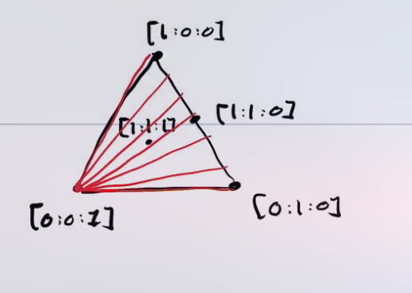

These are in bijection with ${\mathbb{CP}}^1$ since there is always a unique line through $[0:0:1]$ and $[s:t:0]$, where the latter is a copy of ${\mathbb{CP}}^1$ as $s,t$ are allowed to vary. So consider $\mathop{\mathrm{Bl}}_{p}{\mathbb{CP}}^2$ for $p=[0:0:1]$, and consider the strict transforms of the lines $L$ to obtain $\widehat{L} \subset \mathop{\mathrm{Bl}}_p {\mathbb{CP}}^2$. Any two are disjoint since they pass through different slopes of the exceptional divisor. Thus the red lines in the blowup go through distinct slopes, yielding a fibration of ${\mathbb{CP}}^1$s:

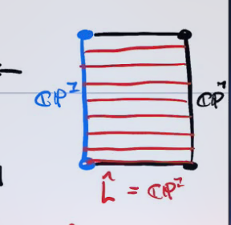

which projects points to the boundary copy of ${\mathbb{CP}}^1$:

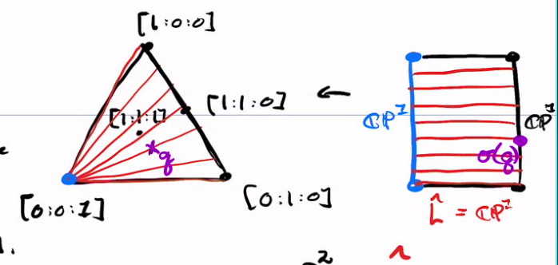

We can’t necessarily project from the blue point itself, but if we add in the data of a tangent vector at that point, the map becomes well-defined. Thus the blowup makes projecting from a point in ${\mathbb{CP}}^2$ to a line in ${\mathbb{CP}}^2$ a well-defined map on $\mathop{\mathrm{Bl}}{\mathbb{CP}}^2$.

This is referred to as ${\mathbb{F}}_1$, the **first Hirzebruch surface**.

For $S\in {\mathsf{Mfd}}_{\mathbb{R}}(C^\infty)$ a smooth manifold, we can identify
$$\begin{align*}
\mathop{\mathrm{Bl}}_p S = S \mathop{ \Large\scalebox{0.8}{\raisebox{0.4ex}{\#}}}\mkern 1.5mu\overline{\mkern-1.5mu{\mathbb{CP}}^2\mkern-1.5mu}\mkern 1.5mu
.\end{align*}$$

It suffices to work in coordinate charts and prove this for $p=0$.

$$\begin{align*}
\mathop{\mathrm{Bl}}_0 {\mathbb{C}}^2 = { \operatorname{Tot} }( {\mathcal{O}}_{{\mathbb{CP}}^1}(-1) )
.\end{align*}$$

Recall that this was the tautological line bundle that whose fibers at a point $p\in {\mathbb{CP}}^1$ was the line in ${\mathbb{C}}^2$ spanned by $p$. We can write this as $\left\{{ [x:y] {~\mathrel{\Big|}~}(x, y) \in L_{[x:y]} }\right\}$:

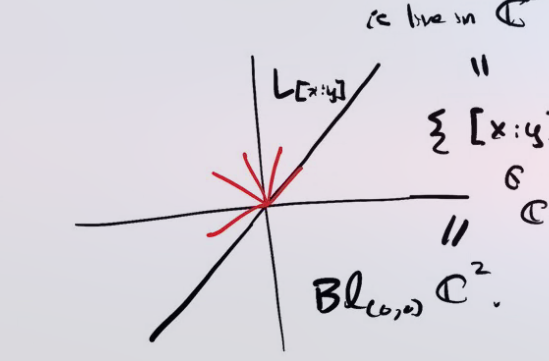

We have ${\mathcal{O}}(-1) \xrightarrow{\sim} \mkern 1.5mu\overline{\mkern-1.5mu{\mathcal{O}}(1)\mkern-1.5mu}\mkern 1.5mu$, where this map is a diffeomorphism that can be constructed using a Hermitian metric. However we can identify ${\mathcal{O}}(1)$ with the set of lines in ${\mathbb{CP}}^2$ through $[0:0:1]$, leaving out the point $[0:0:1]$ itself. This follows by checking that there exists a section that vanishes at only one point. In fact ${ \operatorname{Tot} }{\mathcal{O}}(1)$ is diffeomorphic to the complement of a ball in ${\mathbb{CP}}^2$, which ends up precisely being taking a connect-sum. So we obtain $\mathop{\mathrm{Bl}}_{0} {\mathbb{C}}^2 \cong {\mathbb{C}}^2 \mathop{ \Large\scalebox{0.8}{\raisebox{0.4ex}{\#}}}\mkern 1.5mu\overline{\mkern-1.5mu{\mathbb{CP}}^2\mkern-1.5mu}\mkern 1.5mu$.

Cut out a ball $B^4 \subseteq {\mathbb{C}}^2$, so ${{\partial}}B^4 = S^3 = \left\{{ {\left\lvert {x} \right\rvert}^2 + {\left\lvert {y} \right\rvert}^2 = {\varepsilon}}\right\}$. Then $\mathop{\mathrm{Bl}}_0 {\mathbb{C}}^2$ is the result of collapsing $S^3$ along an $S^1{\hbox{-}}$foliation $(e^{i\theta} x, e^{i\theta}y)$. This has an $S^2$ quotient, yielding the Hopf fibration
$$\begin{align*}
S^1 \hookrightarrow S^3 \to S^2
.\end{align*}$$

Show that the blowup over ${\mathbb{R}}$ is gluing in a mobius strip.

See the Tate curve!

# 39 Friday, April 16

Last time: we defined the blowup $\mathop{\mathrm{Bl}}_0{\mathbb{C}}^2$ as the closure of
$$\begin{align*}
\mathop{\mathrm{Bl}}_0 {\mathbb{C}}^2 \mathrel{\vcenter{:}}={ \operatorname{cl}}
\left\{{ (x, y), [x:y] {~\mathrel{\Big|}~}(x, y) \neq 0 }\right\} \subseteq {\mathbb{C}}^2 \times{\mathbb{CP}}^2
.\end{align*}
This had the effect of adding in all limits of slopes as points approach \((0, 0) \in {\mathbb{C}}^2\). We defined this using local holomorphic coordinate charts to \({\mathbb{C}}^2\). Why is this a complex manifold? We can cover it with charts: given a point \((x, \mu)\) where \(\mu = {y \over x}\in {\mathbb{P}}^1\) is a slope, we can form a first chart by sending
\begin{align*}
(x, \mu) \mapsto \left\{{ (x, x\mu), [1: \mu] }\right\}
.\end{align*}
This yields the first chart, as long as the slope is not infinite, so this applies to all finite slopes. The second chart will work for all nonzero slopes, where we take
\begin{align*}
(v, y)\in {\mathbb{C}}^2 \mapsto \left\{{ (yv, y), [v: 1] }\right\}
.\end{align*}
Note that restricting to \((x, y) = (0, 0)\), these give the standard \({\mathbb{C}}{\hbox{-}}\)charts on \({\mathbb{CP}}^2\). How do these two charts glue? When \(\mu, \nu \neq 0\), we have well-defined transition functions \(\mu = \nu ^{-1}\) and \(x=y\nu\).$$

Recall that for a complex curve $C \in {\mathsf{Mfd}}_{\mathbb{C}}^2$, we have the blowup morphism $\pi: \mathop{\mathrm{Bl}}_pS\to S$ and we defined the **strict transform** $\widehat{C} \mathrel{\vcenter{:}}={ \operatorname{cl}} \pi^{-1}(C\setminus\left\{{{\operatorname{pt}}}\right\})$.

[figure not shown]

Here $E={\mathbb{CP}}^1$ is the exceptional curve of the blowup, and intersects the curve twice. This has the effect of changing $D$ into an embedded curve.

> Note that here $\pi^* D = \widehat{D} + 2E$, where we’ll define this next.

The **pullback** of $C$, denoted $\pi^* C$, is constructed by writing $C = V(f)$ locally. We then set $\pi^* C \mathrel{\vcenter{:}}= V( \pi^* f)$.

Take $C \mathrel{\vcenter{:}}=\left\{{ y=x }\right\} \subset {\mathbb{C}}^2$ and consider $\mathop{\mathrm{Bl}}_0 {\mathbb{C}}^2$. Then
$$\begin{align*}
\widehat{C} \mathrel{\vcenter{:}}={ \operatorname{cl}} \left\{{ \qty{ (x, x), [x:x]} {~\mathrel{\Big|}~}x\neq 0 }\right\} = { \operatorname{cl}} \left\{{ \qty{ (x, x), [1:1] } {~\mathrel{\Big|}~}x\neq 0 }\right\} \subset \mathop{\mathrm{Bl}}_0 {\mathbb{C}}^2
.\end{align*}
By projecting onto the first component, \(\pi:\widehat{C} \xrightarrow{\sim} C\) is an isomorphism. We can compute the pullback: we first have \(\pi^* C = \pi^* V(y-x) = V( \pi^*(y-x))\), so consider \(\pi^*(y-x)\) in the coordinate chart \((x, \mu)\). In this chart, \(y=x\mu\), and so \(\pi^*(y-x) = x\mu - x = x(\mu - 1)\), and so
\begin{align*}
V(\pi^*(y-x)) = V(x) + V(\mu -1) \implies \pi^* C = E + \widehat{C} \text{ as a divisor}
.\end{align*}$$

Take the nodal curve $C = \left\{{ y^2 - x^3 + x^2 }\right\}$:

[figure not shown]

The pullback is then given by
$$\begin{align*}
\pi^* C
&= V( \pi^* (y^2 - x^3 + x^2) ) \\
&= V(\mu^2x^2 -x^3 + x^2) \\
&= V(x^2) + V(\mu^2 - x + 1) \\
&= 2V(x) + V(\mu^2 -x + 1)
.\end{align*}$$

[figure not shown]

In the second coordinate chart, we have
$$\begin{align*}
\pi^* C = V(y^2 - y^4 \nu^3 +y^2 \nu^2) = 2V(y) + V(1-y\nu^3 + \nu^2
.\end{align*}$$

[figure not shown]

Gluing along $\mu, \nu \neq 0$ we get the following picture for $\pi^* C$:

[figure not shown]

Writing $C = \left\{{ x=0 }\right\}$, note that $\widehat{C}$ doesn’t intersect the first coordinate chart. In the $\mu, x$ coordinate chart, for example, we can’t get an infinite slop:

[figure not shown]

## 39.1 Change in Canonical Bundle Formula

Given $\Omega^2_S = K_S \to S$ the canonical line bundle, can we relate $K_{\mathop{\mathrm{Bl}}_p S}$ to $K_S$?

$$\begin{align*}
K_{\mathop{\mathrm{Bl}}_p S} = \pi^* K_S \otimes{\mathcal{O}}_S(E)
.\end{align*}$$

We’ll abbreviate $\widehat{S} \mathrel{\vcenter{:}}=\mathop{\mathrm{Bl}}_p(S)$. Let $\omega$ be a local section of $K_S$ near $p$, and in coordinate charts $(x, y)$, write $\omega = dx \wedge dy$. In the first coordinate chart on the blowup, we can write
$$\begin{align*}
\pi^* \omega = dx \wedge d(x\mu) = dx \wedge (\mu dx + x d\mu) = x\,dx\wedge d\mu
.\end{align*}
Note that \(V(x) = E\), and that pulling back the canonical bundle yields something vanishing to order 1 (?). So \(\pi^* K_S\) is isomorphic to the subsheaf of \(K_{\widehat{S}}\) whose sections vanish along \(E\), which is isomorphic to \(K_{\widehat{S}} \otimes{\mathcal{O}}(-E)\), since the latter are the functions which vanish along \(E\). Tensoring both sides with \({\mathcal{O}}(E)\) yields
\begin{align*}
K_{\widehat{S}} = \pi^* K_S \otimes{\mathcal{O}}_{\widehat{S}}(E)
\end{align*}
as a line bundle, or in divisor notation \(K_{\widehat{S}} = \pi^* K_S + E\) where we take the divisor representing the line bundle instead.$$

Using $\pi: \widehat{S}\to S$, we get pullback maps \begin{align*} \pi^*: H^2(S; {\mathbb{Z}}) &\to H^2(\widehat{S}; {\mathbb{Z}}) \\ \pi^*: \operatorname{Div}(S) &\to \operatorname{Div}(\widehat{S}) .\end{align*} These are compatible in the sense that \begin{align*} [\pi^* C] = \pi^* [C] .\end{align*} . This can be seen by expressing ${\mathcal{O}}_S(C) \cong {\mathcal{O}}_S(A-b)$ for $A, B$ hyperplane section. We can assume $A, B$ avoid $p$ in their projective embeddings, making $[C] = [A] - [B]$ since $c_1({\mathcal{O}}_S(c)) = [C]$ is the fundamental class of $C$. So it suffices to prove the formula for curves *not* passing through $p$, but this is obvious! It follows from the fact that $\pi: \widehat{S} \setminus E \xrightarrow{\sim} S\setminus\left\{{p}\right\}$ is an isomorphism.

In fact,
$$\begin{align*}
H^2(\widehat{S}; {\mathbb{Z}}) \cong \pi^* H^2(S, {\mathbb{Z}}) \oplus {\mathbb{Z}}[E]
.\end{align*}
, which follows from Mayer-Vietoris. So this adds one to the rank.$$

# 40 Monday, April 19

Recall that we have the following:
$$\begin{align*}
H^2(\widehat{S}; {\mathbb{Z}}) = \pi^* H^2(S; {\mathbb{Z}}) \oplus {\mathbb{Z}}[E]
\end{align*}
where \(E\) is the exceptional curve, which follows from Mayer-Vietoris. We can write \(\widehat{S} = S \# \mkern 1.5mu\overline{\mkern-1.5mu{\mathbb{CP}}^2\mkern-1.5mu}\mkern 1.5mu\), and by excision \(H^2(S\setminus{\mathbb{B}}^4) = H^2(S)\). So we get a LES$$

[figure not shown]

> Link to Diagram

We have $H^i(S, S\setminus{\mathbb{B}}^4) = H^i(T, T\setminus{\mathbb{B}}^4) = H^i( {\mathbb{B}}^4, {{\partial}})$, and by Poincaré-Lefschetz duality, this is isomorphic to $H_{4-i}({\mathbb{B}}^4)$. This is equal to 0 if $i\neq 0$ or $4$. Writing $\widehat{S} = (S\setminus{\mathbb{B}}^4) {\textstyle\coprod}_{S^3} (\mkern 1.5mu\overline{\mkern-1.5mu{\mathbb{CP}}^2\mkern-1.5mu}\mkern 1.5mu\setminus{\mathbb{B}}^4)$ and applying Mayer-Vietoris yields

[figure not shown]

> Link to Diagram

Combining this with the isomorphisms from earlier, we can write the direct sum as $H^2(S) \oplus H^2( \mkern 1.5mu\overline{\mkern-1.5mu{\mathbb{CP}}^2\mkern-1.5mu}\mkern 1.5mu)$ where the latter is equal to ${\mathbb{Z}}\ell = [E]$ for $\ell$ a line class.

What is the intersection form on $H^2(\widehat{S}; {\mathbb{Z}})$?

Using the proposition, along with the fact that

1. its an orthogonal decomposition,
2. $\pi^*$ is an isometry, and
3. $[E]^2 = -1$,

we know that the Gram matrix for $H^2(\widehat{S})$ is the same as that for $H^1(S) \oplus [-1]$, i.e. it is of the form
$$\begin{align*}
\begin{bmatrix}
A & 0
\\
0 & -1
\end{bmatrix}
.\end{align*}$$

Consider $[\Sigma_1], [\Sigma_2]\in H^2(S; {\mathbb{Z}})$ where the $\Sigma_i$ are real surfaces, and suppose $\Sigma_1 \pitchfork\Sigma_2$ and $p\not\in \Sigma_1, \Sigma_2$. We then have
$$\begin{align*}
[ \pi^{-1}( \Sigma_i ) ] = \pi^* [ \Sigma_i ]
.\end{align*}$$

[figure not shown]

The intersection number is preserved because $\pi$ is generically injective.

It also follows that if $p\not\in \Sigma$, $\pi^*[\Sigma] = [\pi^{-1}\Sigma]$ where the latter is disjoint from $E$. So $\pi^*[\Sigma] \cdot E = 0$.

Since $[E] \sim [\text{line}] \in \mkern 1.5mu\overline{\mkern-1.5mu{\mathbb{CP}}^2\mkern-1.5mu}\mkern 1.5mu\setminus{\mathbb{B}}^4$, and $E^2 = [E] \cdot [E] = -1$ since the orientations disagree in $\mkern 1.5mu\overline{\mkern-1.5mu{\mathbb{CP}}^2\mkern-1.5mu}\mkern 1.5mu$.

Let $C \subset S$ be a curve on a surface and suppose $C$ is locally cut out by
$$\begin{align*}
f(x, y) = a_{m, 0} x^m + a_{n-1, 1} x^{m-1} y + \cdots + a_{0, m} y^m + O(x^{m+1}, y^{m+1})
,\end{align*}
near \(p\in S\), so the lowest order terms in the Taylor expansion are degree \(m\). Then
\begin{align*}
\pi^* C = \widehat{C} + mE
.\end{align*}$$

On the blowup, take local coordinates $(x, \mu)$ where $y = x\mu$ and write
$$\begin{align*}
V(\pi^* f)
&= V( x^m \qty{a_{m, 0} + a_{m-1, 1} \mu + \cdots + a_{0, m} \mu^m + O(x^{m+1}, \mu^{m+1} ) } ) \\
&= m V(x) + V( a_{m, 0} + \cdots ) \\
&= E + \widehat{C}
.\end{align*}$$

Take
$$\begin{align*}
C = \left\{{ y^2 = x^3-x^2 }\right\} \subseteq {\mathbb{C}}^2
,\end{align*}
where \(\mathop{\mathrm{Bl}}_0 {\mathbb{C}}^2 \to C\). Then \(\pi^* C = \widehat{C} + 2E\), so
\begin{align*}
C = V(x^2 + y^2 + O(\deg(3))
.\end{align*}
.$$

$\widehat{C}^2 = C^2 - m^2$.

Write $\pi^* C = \widehat{C} + mE$, then $\widehat{C} = \pi^* C - mE$ implies that $\widehat{C}^2 = (\pi^* C - mE)^2$. This equals
$$\begin{align*}
(\pi^* C)^2 - 2m \pi^* C\cdot E + m^2 E^2
&= C^2 - 0 - m^2 \\
&= C^2 - m^2
,\end{align*}
where we’ve used (2), (1), and (3) respectively to identity these terms.$$

Let
$$\begin{align*}
C\mathrel{\vcenter{:}}=\left\{{ zy^2 = x^3 - x^2 z }\right\} \subset {\mathbb{CP}}^2
,\end{align*}
then \(C^2 = (3\ell)^2 = 9\). The multiplicity of \(C\) at the point \([0:0:1]\) is 2. Taking the coordinate chart \(\left\{{ z=1 }\right\} \cong {\mathbb{C}}^2\), we recover the curve \(y^2 = x^3 - x^2\) which has multiplicity 2 at \((0, 0)\). We can conclude \(\widehat{C} = \mathop{\mathrm{Bl}}_{[0:0:1]} {\mathbb{CP}}^2\) has self-intersection number \(\widehat{C}^2 = 9-2^2 = 5\).$$

Let $S$ be a complex surface and let $E \subset S$ be a holomorphically embedded ${\mathbb{CP}}^2$ such that $E^2 = -1$ Then there exists a smooth surface $\mkern 1.5mu\overline{\mkern-1.5muS\mkern-1.5mu}\mkern 1.5mu$ and $p\in \mkern 1.5mu\overline{\mkern-1.5muS\mkern-1.5mu}\mkern 1.5mu$ such that $S = \mathop{\mathrm{Bl}}_p \mkern 1.5mu\overline{\mkern-1.5muS\mkern-1.5mu}\mkern 1.5mu$ with $E$ as the exceptional curve.

This $\mkern 1.5mu\overline{\mkern-1.5muS\mkern-1.5mu}\mkern 1.5mu$ is called the **blowdown** of $S$ along $E$.

Note that this is the exact situation when we blow things up. This is a converse: if we have something that looks like a blowup, we can find something that blows up to it.

Show that the category ${\mathsf{Mfd}}_{\mathbb{C}}$ is not closed under blowdowns, i.e. there is no blowdown of a holomorphically embedded ${\mathbb{CP}}^1$, say $E$, with $E^2 = 1$.

> Hint: think about ${\mathbb{CP}}^2$.

This is interesting because there does exist a blowdown in the smooth category ${\mathsf{Mfd}}(C^\infty({\mathbb{R}}))$. This is because $S \to S\# \mkern 1.5mu\overline{\mkern-1.5mu{\mathbb{CP}}^2\mkern-1.5mu}\mkern 1.5mu$ and $S\to S\# {\mathbb{CP}}^2$ are indistinguishable here. One can just reverse orientations.

A complex surface with a holomorphically embedded ${\mathbb{CP}}^1$ of self intersection $-1$. Let $p, q\in {\mathbb{CP}}^2$ be distinct points, and let $\mathop{\mathrm{Bl}}_{p, q} {\mathbb{CP}}^2 \mathrel{\vcenter{:}}=\mathop{\mathrm{Bl}}_p \mathop{\mathrm{Bl}}_q {\mathbb{CP}}^2$. Note that these two operations commute since these are distinct points and blowing up is a purely local operation. Let $\ell \subset {\mathbb{CP}}^2$ be the unique line through $p$ and $q$. Viewing $p, q$ as lines in ${\mathbb{C}}^3$, they span a unique plane, which is a line in projective space, so this makes sense and we can write $\ell \approx {\operatorname{span}}\left\{{ p, q }\right\}$. Since $\ell$ is defined by a linear equation in local coordinates near $p, q$, we have ${\operatorname{mult}}_p \ell = {\operatorname{mult}}_q \ell = 1$. We hve
$$\begin{align*}
\widehat{\ell} = \pi^* \ell - E_p - E_q \\
\widehat{\ell}^2 = \ell^2 - 1^2 - 1^2 = 1-1-1 = - 1
.\end{align*}
Under \(\pi: \mathop{\mathrm{Bl}}_{p, q} {\mathbb{CP}}^2 \to {\mathbb{CP}}^2\), we have \(\widehat{\ell} \xrightarrow{\sim} \ell\).$$

[figure not shown]

Here since all of the lower order terms have degree 1, there is a well-defined tangent line. Since $\ell \cong {\mathbb{CP}}^2$, we have $\widehat{\ell }\cong {\mathbb{CP}}^2$. Letting $\sigma$ be the blowdown of $\widehat{\ell}$, we have

[figure not shown]

> [Link to Diagram](https://q.uiver.app/?q=WzAsMyxbMSwwLCJcXEJsX3twLCBxfVxcQ1BeMiJdLFsyLDIsIlxcQ1BeMiJdLFswLDIsIlxcQ1BeMSBcXGNyb3NzIFxcQ1BeMSJdLFswLDIsIlxcc2lnbWEiLDJdLFswLDEsIlxccGkiXV0=)

There’s a way to do this with Kirby Calculus.

# 41 Wednesday, April 21

Why can’t one blow down a curve $E\cong {\mathbb{CP}}^1$ with $E^2 = 1$ in a complex surface? Disproof: consider $S\mathrel{\vcenter{:}}={\mathbb{CP}}^2$ and $E$ a line, where $E^2 = 1$. If there were a blowdown in the complex analytic category
$$\begin{align*}
S &\to \mkern 1.5mu\overline{\mkern-1.5muS\mkern-1.5mu}\mkern 1.5mu \\
E &\mapsto {\operatorname{pt}}
.\end{align*}
But \(\mkern 1.5mu\overline{\mkern-1.5muS\mkern-1.5mu}\mkern 1.5mu \cong_{\mathsf{Top}}S^4\), since \(S^4 \# {\mathbb{CP}}^2 \cong {\mathbb{CP}}^2\), and this would yield a complex structure on \(S^4\) – a contradiction. This also follows because \(\mkern 1.5mu\overline{\mkern-1.5muS\mkern-1.5mu}\mkern 1.5mu \in \mathbb{Z}\operatorname{HS}^4\), and Noether’s formula implies that every \(\mathbb{Z}\operatorname{HS}^4\) has no complex structure.$$

Recall that we were considering the following:

[figure not shown]

> [Link to Diagram](https://q.uiver.app/?q=WzAsMyxbMSwwLCJcXEJsX3twLCBxfVxcQ1BeMiJdLFsyLDIsIlxcQ1BeMiJdLFswLDIsIlxcQ1BeMSBcXGNyb3NzIFxcQ1BeMSJdLFswLDIsIlxcc2lnbWEiLDJdLFswLDEsIlxccGkiXV0=)

Let $\mkern 1.5mu\overline{\mkern-1.5mu\ell\mkern-1.5mu}\mkern 1.5mu \subset \mathop{\mathrm{Bl}}_{p, q}({\mathbb{CP}}^2)$ the strict transform of a line through $p, q$ with $\widehat{\ell}^2 = -1$. Goal: we want to construct the map $\sigma$ sending $\widehat{\ell}$ to a single point. Let $r\in \mathop{\mathrm{Bl}}_{p, q}{\mathbb{CP}}^2$, then there are three possibilities:

1. $r\in {\mathbb{CP}}^2 \setminus\left\{{ p, q }\right\}$
2. $r\in E_p$
3. $r\in E_q$

If a point $r \neq p, q$, we can take lines $\ell_{pr}. \ell_{qr}$. We can take slopes of these lines to get points in ${\mathbb{CP}}^1$, and in fact it’s the exceptional divisor (since these are sets of slopes through a point).

So we can map
$$\begin{align*}
r \mapsto
\begin{cases}
( {\mathrm{slope}}_p \ell_{pr}, {\mathrm{slope}}_q \ell_{qr} ) \in {\mathbb{CP}}^2 \times{\mathbb{CP}}^2
& \text{Case 1}
\\
(r, {\mathrm{slope}}_q \ell_{qp} )
& \text{Case 2}
\\
({\mathrm{slope}}_p \ell_{pq}, r)
&\text{Case 3}
.
\end{cases}
\end{align*}
This is clearly continuous, is this injective? The outputs will be the same for any point on the line between \(p\) and \(q\):$$

[figure not shown]

So this realizes the blowdown map, since $\Phi \widehat{\ell}_{pq} ) = {\operatorname{pt}}$ and restricting it to the complement of the line is injective.

## 41.1 Spin and Spinc Groups

Goal: show that $3[\ell]$ can’t be realized by a sphere, we’ll need Rohklin’s theorem for this. Let $(V, {\left\langle {{-}},~{{-}} \right\rangle})$ be an inner product space, and assume the inner product is positive-definite. Recall that the tensor algebra is defined as $T(V) \mathrel{\vcenter{:}}=\bigoplus _{n\geq 0} V^{\otimes n}$.

Define the **Clifford Algebra** of $V$ as
$$\begin{align*}
{ \operatorname{Cl}} (V) \mathrel{\vcenter{:}}= T(V) / \left\langle{ v\otimes v + {\left\lVert {v} \right\rVert}^2 1 }\right\rangle
.\end{align*}$$

Take ${\mathbb{R}}$ with the standard inner product, so ${\left\langle {x},~{y} \right\rangle} \mathrel{\vcenter{:}}= xy$. Then $T({\mathbb{R}}) = \bigoplus _{n\geq 0} {\mathbb{R}}$. Letting $\left\{{ e }\right\}$ be a basis of ${\mathbb{R}}$, we have $T({\mathbb{R}}) = {\mathbb{R}}\oplus {\mathbb{R}}e \oplus {\mathbb{R}}(e^2) \oplus \cdots \cong {\mathbb{R}}[x]$ by sending $e^n\mapsto x^n$. Since ${\left\lVert {e} \right\rVert} = 1$, and we mod out by $e^2 + {\left\lVert {e} \right\rVert}^2 1$ where $e^2 = -1$ and thus
$$\begin{align*}
{ \operatorname{Cl}} ({\mathbb{R}}, {\left\langle {{-}},~{{-}} \right\rangle}_\text{std}) \cong {\mathbb{R}}[x] / \left\langle{ x^2 = -1 }\right\rangle\cong {\mathbb{C}}
.\end{align*}
The denominator is referred to as the Clifford relation.$$

Take ${\mathbb{R}}^2$ with the standard inner product and an orthonormal basis $\left\{{ e_1, e_2 }\right\}$. Then
$$\begin{align*}
T({\mathbb{R}}) = {\mathbb{R}}\oplus {\mathbb{R}}\left\langle{ e_1, e_2 }\right\rangle \oplus {\mathbb{R}}\left\langle{ e_1^2, e_1e_2, e_2 e_1, e_2^2 }\right\rangle \oplus \cdots
.\end{align*}
Note that there are \(2^k\) terms in the \(k\)th graded piece. It suffices to mod out only by the relations on the orthonormal basis. This is of the form \((v+w)^2 = - {\left\lVert {v+w} \right\rVert}^2 = -{\left\lVert {v} \right\rVert}^2 - 2{\left\langle {v},~{w} \right\rangle} - {\left\lVert {w} \right\rVert}^2\). On the other hand, this equals \(v^2 + vw + wv + w^2\). So we obtain
\begin{align*}
vw + wv = 2{\left\langle {v},~{w} \right\rangle}
,\end{align*}
and setting \(v=w\) and dividing by 2 yields the original Clifford relation.$$

For ${\mathbb{R}}^2$, we can explicitly check

1. $e_1^2 = -1$,
2. $e_2^2 = -1$,
3. $e_1e_2 + e_2 e_1 = -2e_1 e_2 = 0$,
4. $e_1 e_2 = -e_2 e_1$.

Here (1), (2), and (4) generate all of the relations, so
$$\begin{align*}
{ \operatorname{Cl}} ({\mathbb{R}}^2) - {\mathbb{R}}\left\langle{ e_1, e_2 }\right\rangle / \left\langle{ e_1^2 = -1, e_2^2 =-1, e_1e_2 = -e_2 e_1 }\right\rangle \cong HH
.\end{align*}
We can form this map by
\begin{align*}
1 &\mapsto 1 \\
e_1 &\mapsto i \\
e_2 &\mapsto j \\
e_1 e_2 &\mapsto k
,\end{align*}
and then checking that the appropriate relations hold. These hold since \(i^2 = j^2 = -1\) and \(ij=-ji = k\). These suffice, but you can check the rest: for example, does \(jk=i\) hold? We can write this as
\begin{align*}
e_2(e_1e_2) = -e_2 (e_2 e_1) = -e_2^2 e_1 = -(-1)e_1 = e_1
.\end{align*}$$

Check that $\dim_{\mathbb{R}}{ \operatorname{Cl}} (V) = 2^{\dim V} < \infty$.

# 42 Friday, April 23

Given $(V, \cdot)$ an inner product space, we defined
$$\begin{align*}
{ \operatorname{Cl}} (V) \mathrel{\vcenter{:}}={ \bigoplus _{n\geq 0} V^{\otimes n} \over \left\langle{ v\otimes w + w\otimes v = 2v\cdot w }\right\rangle }
.\end{align*}$$

We saw that
$$\begin{align*}
{ \operatorname{Cl}} ({\mathbb{R}}, \cdot)
&\cong {\mathbb{R}}[e] / e^2
=-1 \cong {\mathbb{C}}\\
{ \operatorname{Cl}} ({\mathbb{R}}^2, \cdot)
&= {\mathbb{R}}\left\langle{ e_1, e_2 }\right\rangle / \left\langle{ e_1^2 = e_2^2 = -1, e_1e_2 = -e_2 e_1 -}\right\rangle \cong {\mathbb{H}}
\end{align*}
where \(e_1\mapsto i, e_2\mapsto j, e_3 = e_1 e_2 \mapsto k\). Can we describe \({ \operatorname{Cl}} ({\mathbb{R}}^n, \cdot)\) in general? Choose an orthonormal basis \(\left\{{ e_i }\right\}\), then
\begin{align*}
{ \operatorname{Cl}} ({\mathbb{R}}^n, \cdot) = { {\mathbb{R}}\left\langle{ e_1, \cdots, e_n }\right\rangle \over \left\langle{ e_i^2 = -1, e_i e_j = -e_j e_i {~\mathrel{\Big|}~}i\neq j }\right\rangle }
.\end{align*}
We saw that replacing \(2\) with \(\epsilon\) in the defining relation recovers \(\bigwedge\nolimits^* V\).$$

Define the **degree filtration** on ${ \operatorname{Cl}} (V, \cdot)$ as the filtration induced by the degree filtration on $T(V) \mathrel{\vcenter{:}}=\bigoplus _{n\geq 0} V^{\otimes n}$.

Consider ${ \operatorname{Cl}} ({\mathbb{R}}^2, \cdot)$. Then

- Degree 0: ${\mathbb{R}}$.
- Degree 1: ${\mathbb{R}}\oplus {\mathbb{R}}e_1 \oplus {\mathbb{R}}e_2$
- Degree 2: ${\mathbb{R}}\oplus {\mathbb{R}}e_1 \oplus {\mathbb{R}}e_2 \oplus {\mathbb{R}}e_1 e_2$

Recall that there’s a distinction between gradings and filtration:

- Gradings: $R^i R^j \subset R^{i+j}$ and $R = \bigoplus_i R^i$.
- Filtrations: $F^1 \subset F^2 \subset \cdots$ with $F^i F^j \subseteq F^{i+j}$

An algebra equipped with a grading is a **graded algebra**, and similarly an algebra equipped with a filtration is a **filtered algebra**.

Note that

- $k[x_1, \cdots, x_n]$ is graded (by monomials of uniform degree) and filtered (by polynomials of a bounded degree)
- $T(V)$ is graded and filtered, since multiplying a pure $p$ tensor with a pure $q$ tensor yields a pure $p+q$ tensor
- ${ \operatorname{Cl}} (V)$ is a quotient of $T(V)$, but one can’t simply define ${ \operatorname{Cl}} (V, \cdot)^i = \operatorname{im}T(V)^i$ since the relations have mixed degree: for example $e_1^2 = -1$ So ${ \operatorname{Cl}} (V)$ isn’t graded, but is still filtered: take the filtration $F$ on $T(V)$ defined by $F^i \mathrel{\vcenter{:}}=\bigoplus _{j\leq i} V^{\otimes j}$ and descend it through the quotient map. The relations can only decrease degree, so this is well defined.

Define a filtration $F^{-}$ on ${ \operatorname{Cl}} (V)$ by the following:
$$\begin{align*}
F^i { \operatorname{Cl}} (V) \mathrel{\vcenter{:}}={\operatorname{span}}\left\{{ { {e_j}_1, {e_j}_2, \cdots, {e_j}_{i}} }\right\}
.\end{align*}$$

The **associated graded** ring ${\mathsf{gr}\,}_{F^{-}} R$ is the graded ring defined by
$$\begin{align*}
({\mathsf{gr}\,}_{F^{-}})^i \mathrel{\vcenter{:}}= F^i R / F^{i-1} R
.\end{align*}
This induces a decomposition
\begin{align*}
{\mathsf{gr}\,}_{F^{-}} \cong \bigoplus _{i\geq 0} F^i R/ F^{i-1} R = \bigoplus _{i\geq 0} ({\mathsf{gr}\,}_{F^{-}})^i
,\end{align*}
which has a multiplicative structure
\begin{align*}
F^i/F_{i-1} \cdot F^j/F_{j-1} \to F^{i+j} / F^{i+j-1}
.\end{align*}$$

Note that if $R \in {\mathsf{gr}\,}\mathsf{Ring}$, then ${\mathsf{gr}\,}(R) = R$, so taking the associated graded recovers the ring itself. What’s happening: taking the smallest homogeneous ideal.

If one has relations of mixed degree, the associated graded also has the top degree part of each relation.

In our case, the Clifford relation relates degree $k$ pieces to degree $k-2$ pieces, so we obtain
$$\begin{align*}
{\mathsf{gr}\,}_{F^{-}} { \operatorname{Cl}} (V) \cong T(V) / \left\langle{ v\otimes w + w\otimes v = 0 }\right\rangle \mathrel{\vcenter{:}}=\bigwedge\nolimits^* V
.\end{align*}
There is an isomorphism of \(k{\hbox{-}}\)vector spaces
\begin{align*}
{ \operatorname{Cl}} (V) & \xrightarrow{\sim} {\mathsf{gr}\,}{ \operatorname{Cl}} (V) \\
x\in F^i &\mapsto \mkern 1.5mu\overline{\mkern-1.5mux\mkern-1.5mu}\mkern 1.5mu \in F^i / F^{i-1}
.\end{align*}
This is because \(F^0 \subseteq \cdots \subseteq \cdots\) with \(\cup_i F^i = { \operatorname{Cl}} (V)\). We can conclude \(\dim_{\mathbb{R}}{ \operatorname{Cl}} (V) = \dim_{\mathbb{R}}\bigwedge\nolimits^* V = 2^{\dim_k V}\) and use this to construct a basis for \({ \operatorname{Cl}} (V)\). The relevant map is
\begin{align*}
{ {e_j}_1, {e_j}_2, \cdots, {e_j}_{i}} &\mapsto e_{j_1} \wedge \cdots \wedge e_{j_i}
.\end{align*}$$

The following set forms an ${\mathbb{R}}{\hbox{-}}$basis for ${ \operatorname{Cl}} ({\mathbb{R}}^n, \cdot)$:
$$\begin{align*}
\left\{{ { {e_j}_1, {e_j}_2, \cdots, {e_j}_{i}} {~\mathrel{\Big|}~}j_1 < j_2 < \cdots < j_i,\, i\leq n }\right\}
.\end{align*}$$

Consider
$$\begin{align*}
{ \operatorname{Cl}} ({\mathbb{R}}^3, \cdot) \cong {\operatorname{span}}_{\mathbb{R}}\left\{{ 1, e_1, e_2, e_3, e_1e_2, e_1 e_3, e_1 e_2 e_3 }\right\}
.\end{align*}
Then
\begin{align*}
e_1 e_2 \cdot e_1 e_3
&= -e_1 e_1 e_3 e_3
&& e_2 e_1 = -e_1 e_2 \\
&= e_2 e_3
&& e_1^2 = - 1
.\end{align*}$$

Show that ${ \operatorname{Cl}} ({\mathbb{R}}^3) \cong {\mathbb{H}}\oplus {\mathbb{H}}$.

${ \operatorname{Cl}} (V)$ has a ${\mathbb{Z}}/2$ (“super”) grading, so
$$\begin{align*}
{ \operatorname{Cl}} (V) \circ { \operatorname{Cl}} _0(V) \oplus { \operatorname{Cl}} _1(V) && { \operatorname{Cl}} _i(V) \cdot { \operatorname{Cl}} _j(V) \subset { \operatorname{Cl}} _{i+j\pmod 2}(V)
.\end{align*}
The even subalgebra is given by
\begin{align*}
{ \operatorname{Cl}} _0(V) = {\operatorname{span}}_k \left\{{ { {e_i}_1, {e_i}_2, \cdots, {e_i}_{2k}} {~\mathrel{\Big|}~}2k\leq n }\right\}
,\end{align*}
where we take an even number of basis elements, which makes sense because the Clifford relation \(vw + 2v = -2v\cdot w\) preserves degree mod 2. This is still an algebra. The odd sub-vector space (not an algebra) is given by
\begin{align*}
{ \operatorname{Cl}} _1(V) = {\operatorname{span}}_k \left\{{ { {e_i}_1, {e_i}_2, \cdots, {e_i}_{2k+1}} {~\mathrel{\Big|}~}2k+1\leq n }\right\}
.\end{align*}$$

$$\begin{align*}
{ \operatorname{Cl}} ({\mathbb{R}}^3) = {\operatorname{span}}_{\mathbb{R}}\left\{{ 1, e_1 e_2, e_1 e_3, e_2 e_3 }\right\}
,\end{align*}
and we saw \(e_1 e_2 = e_1 e_3 = e_2 e_3\). This product has degree 4, and when we applied the relation \(e_1^2=1\) we dropped the degree by 2. For the odd part, \(e_3 \in Cl_1({\mathbb{R}}^3)\) and \(e_1 e_2 \in { \operatorname{Cl}} _0({\mathbb{R}}^3)\), and we have
\begin{align*}
e_3 \cdot (e_1 e_2) = -e_1 e_3 e_2 = e_1 e_2 e_3 \in { \operatorname{Cl}} _1({\mathbb{R}}^3)
.\end{align*}$$

$$\begin{align*}
{ \operatorname{Cl}} (V) \cong { \operatorname{Cl}} _0(V \oplus {\mathbb{R}})
.\end{align*}$$

Let $e\in {\mathbb{R}}$ be a unit vector. Given $x\in { \operatorname{Cl}} (V)$, decompose $x = x_0 + x_1 \in { \operatorname{Cl}} _0(V) \oplus { \operatorname{Cl}} _1(V)$. Define an isomorphism
$$\begin{align*}
\phi: { \operatorname{Cl}} (V) &\to { \operatorname{Cl}} _0(V \oplus {\mathbb{R}}) \\
x &\mapsto x_0 + x_1 e
,\end{align*}
which is well-defined since \(x_0\) was odd degree, and both \(x_1, e\) were odd degree and thus \(x_1 e\) is even. One checks that this preserves multiplication:
\begin{align*}
x\cdot y = (x_0 + x_1) \cdot (y_0 + y_1) = (x_0 y_0 + x_1 y_1) + (x_0 y_1 + x_1 y_0) \in { \operatorname{Cl}} _0(V) \oplus { \operatorname{Cl}} _1(V)
,\end{align*}
and so
\begin{align*}
\phi(x) \cdot \phi(y)
&= (x_0 +x_1 e)(y_0 + y_1 e) \\
&= x_0 y_0 + x_0 y_1 e + x_1 e y_0 + x_1 e y_1 e_1
.\end{align*}
The question is if this equals
\begin{align*}
\phi(xy) \mathrel{\vcenter{:}}=(x_0 y_0 + x_1 y_1) + (x_0 y_1 + x_1 y_0)e
.\end{align*}
But for example, \(x_1 e y_0 = (-1)^{|y_0|} x_1 y_0 e\), and \(y_0\) is even. Similarly, \(x_1 e y_1 e = -x_1 y_1 e^2 = x_1 y_1\).$$

# 43 Wednesday, April 28

Last time: we defined ${\operatorname{Pin}}(n) \subseteq { \operatorname{Cl}} ({\mathbb{R}}^n)$ which was generated by $S^1({\mathbb{R}}^n)$. These were units because $v^2 = -{\left\lVert {v} \right\rVert}^2 = -1$, so $v^{-1}= -v$, and formed a group contained in ${ \operatorname{Cl}} ({\mathbb{R}}^n)^{\times}$. There is a decomposition ${ \operatorname{Cl}} (V) = { \operatorname{Cl}} _0(V) \oplus { \operatorname{Cl}} _1(V)$ with a ${\mathbb{Z}}/2{\hbox{-}}$grading, and we defined
$$\begin{align*}
{\operatorname{Spin}}(V) \mathrel{\vcenter{:}}={\operatorname{Pin}}(V) \cap{ \operatorname{Cl}} _0(V) = \left\langle{ vw {~\mathrel{\Big|}~}v,w\in S^1({\mathbb{R}}^n) }\right\rangle
.\end{align*}
There is a map
\begin{align*}
{\operatorname{Pin}}(n) &\twoheadrightarrow O(n) \\
v & \mapsto (u\mapsto vuv^{-1}) = -R_{v^\perp}
,\end{align*}
which preserves \(V^{\otimes 1} \subset { \operatorname{Cl}} (V)\), and was reflection about the hyperplane \(v^\perp\). There is also a SES
\begin{align*}
0 \to {\mathbb{Z}}/2 \to {\operatorname{Spin}}(n) \xrightarrow{\pi} {\operatorname{SO}}(n) \to 0
,\end{align*}
where we used the fact that \(\ker \pi \subset Z{ \operatorname{Cl}} ({\mathbb{R}}^n)\). It turns out that \({\operatorname{Spin}}(n) = \overline{ {\operatorname{SO}}(n) }\), using that \(\pi_1( {\operatorname{SO}}(n), {\operatorname{pt}}) = {\mathbb{Z}}/2\) and checking that \(\pm 1\in {\operatorname{Spin}}(n)\), yielding a nontrivial kernel.$$

This is local, at a single vector space, so we’ll now try to globalise this to the tangent space of a manifold.

Let $(V, g)$ be an oriented smooth Riemannian manifold where $g$ is a metric on $TX$. Define the **Clifford bundle** of $X$ by
$$\begin{align*}
{ \operatorname{Cl}} (X) \mathrel{\vcenter{:}}={ \operatorname{Cl}} (T {}^{ \vee }X, g {}^{ \vee })
,\end{align*}
where we’ve used the dual metric \(g {}^{ \vee }\) on the cotangent bundle.$$

We showed that ${\mathsf{gr}\,}{ \operatorname{Cl}} ({\mathbb{R}}^n) = \bigwedge\nolimits{\mathbb{R}}^n$, and so there is a bundle isomorphism
$$\begin{align*}
{ \operatorname{Cl}} (X) \xrightarrow{\sim} \bigwedge\nolimits^* T {}^{ \vee }X
,\end{align*}
but the ring structure is different. On the right, we have a way of multiplying sections, namely \(\omega_1 \wedge \omega_2\), but on the left we have the Clifford multiplication \(\alpha_1 \cdot \alpha_2\). Note that \(\omega^{\wedge 2} = 0\), but \(\alpha^{\cdot 2} \in {\mathbb{R}}\) is some scalar. We define \(\omega\cdot \omega= g^*( \omega, \omega)\), so we use the metric fiberwise to define a Clifford multiplication.$$

Given an oriented bundle with a metric, there is a principal ${\operatorname{SO}}(n)$ bundle $P \mathrel{\vcenter{:}}=\mathop{\mathrm{OFrame}}$, the space of orthogonal oriented frames.

This is principal since any two elements are related by a unique element of ${\operatorname{SO}}(n)$. Recall that we had an *associated bundle* construction, so taking the standard representation $\rho: {\operatorname{SO}}(n) \to ({\mathbb{R}}^n, g)$ where elements act by their transformations (?), there is an oriented bundle $P { \underset{\scriptscriptstyle {\rho} }{\times} } {\mathbb{R}}^n$. If the bundle is $TX$ with a metric $g$, this yields a distinguished ${\operatorname{SO}}(n)$ bundle $P\to X$.

A **spin structure** is a lift $\tilde P$ of $P$ to a principal ${\operatorname{Spin}}(n)$ bundle.

$X$ admits a spin structure iff the second Stiefel–Whitney class $w_2(X) = 0$ in $H^2(X; {\mathbb{Z}}/2)$. If $w_2(X) = 0$, then the spin structures are torsors over $H^1(X; {\mathbb{Z}}/2)$.

Recall that a $G{\hbox{-}}$torsor is a set with a free transitive $G{\hbox{-}}$action. For example, the fibers of a principal bundle are torsors. Given any two torsors, we can compare them using elements of $G$, but there is no distinguished element. For example, ${\mathbb{A}}_n$ is a torsor over the vector space $k^n$.

Consider transitions for $P\to X$:
$$\begin{align*}
t_{ij}: U_i \cap U_j \to {\operatorname{SO}}(n) \\
,\end{align*}
where \(t_{ij} = t^{-1}_{ji}\) and the cocycle condition \(t_{ij} t_{jk} t_{ki} = 1\) is satisfied. We want a lift:$$

[figure not shown]

> Link to Diagram

We can always lift to *some* $\tilde t_{ij}$ using the path-lifting property of covers if $U_i \cap U_j$ is contractible, using that ${\mathbb{Z}}/2$ is discrete. We can arrange $\tilde t_{ij} = \tilde t_{ji}^{-1}$ since $U_i \cap U_j = U_j \cap U_i$, but we may not have the cocycle condition on the lift. We have $t_{ij} t_{jk} t_{ki} = 1$, so
$$\begin{align*}
\tilde t_{ij} \tilde t_{jk} \tilde t_{ki} \in \ker ({\operatorname{Spin}}(n) \to {\operatorname{SO}}(n)) = \left\{{ \pm 1 }\right\}
,\end{align*}
using that everything in sight needs to be a group morphism. So define
\begin{align*}
\tilde t_{ijk} \mathrel{\vcenter{:}}=( \tilde t_{ij} \tilde t_{jk} \tilde t_{ki} )_{i,j,k} \in {\check{C}}^2_{\mathcal{U}}(X, \underline{{\mathbb{Z}}/2})
.\end{align*}
The claim is that \({{\partial}}^2( \tilde t_{ijk}) = 0\), but it turns out that regardless of choice of lift we obtain
\begin{align*}
{{\partial}}^2(\tilde t_{ijk}) = \tilde t_{ijk} \tilde t_{ikl}^{-1}\tilde t_{ijl} \tilde t_{ijk}^{-1}= 0 \implies [ \tilde t_{ijk} ] \in {\check{H}}^2(X, \underline{{\mathbb{Z}}/2})
.\end{align*}$$

Is this class well-defined? Consider replacing $\tilde t_{ij}$ with $-\tilde t_{ij}$. In general, we have
$$\begin{align*}
i, j\in \left\{{ a,b,c }\right\} \implies \tilde t_{abc} \mapsto -\tilde t_{abc}
,\end{align*}
and so this is a Čech coboundary in \({{\partial}}^1(1, \cdots, 1, -1, 1, \cdots, 1)\) where the \(-1\) occurs in the \(t_{ij}\) coordinate. Thus \(\tilde t_{ijk}\) is well-defined moduli \({{\partial}}^1 C_{\mathcal{U}}^1(X, \underline{{\mathbb{Z}}/2})\).$$

Note that $w_2(X)$ was produced from the pair $(X, g)$, but the space of metrics is connected and thus $w_2(X)$ depends only on $X$. Suppose $w_2(X) = 0$, then $[ \tilde t_{ijk} ] = 0$ which implies that there is some $(s_{ij})$ with ${{\partial}}^1 (s_{ij}) = (\tilde t_{ijk})$. So replace each $\tilde t_{ij}$ with $\tilde{ \tilde t}_{ij} \mathrel{\vcenter{:}}= s_{ij} \tilde t_{ij}$ is a new lift which satisfies the cocycle condition. Thus they define the transition functions of a principal ${\operatorname{Spin}}(n)$ bundle lifting $P \to X$.

To see the claim about torsors, given any $\ell_{ij} \in \ker {{\partial}}^1$, note that any $\tilde{ \tilde t}_{ij} \ell_{ij}$ also satisfies the cocycle condition. There is a map
$$\begin{align*}
\left\{{ \text{Spin structures} }\right\} &\leftarrow\ker {{\partial}}^1 \\
\tilde{\tilde t}_{ij} \ell_{ij} &\mapsfrom \ell_{ij}
,\end{align*}
which is a torsor because we needed to start with a given lift \(\tilde{\tilde t}_{ij}\). Then \(\tilde P_1 \cong \tilde P_2\) iff there exists an \((m_i) \in {\check{C}}^0_{\mathcal{U}}(X, \underline{{\mathbb{Z}}/2})\) such that \((\ell_{ij})_1 = (\ell_{ij})_2 + {{\partial}}^0 (m_i)\), which are different trivializations of the same bundle.$$

This is a nice example to get a hang of the use and importance of Čech cohomology. We then use the isomorphism ${\check{H}}\to H_{{\operatorname{Sing}}}$.

Assume $n \mathrel{\vcenter{:}}=\dim V$ is even, then ${ \operatorname{Cl}} (V)$ has a unique nontrivial irreducible finite dimensional complex representation $S$ of dimension $\dim S = 2^{n/2}$, the **spin representation**.

It turns out that ${ \operatorname{Cl}} (V) \otimes_{\mathbb{R}}{\mathbb{C}}\cong \mathop{\mathrm{End}}(S)$. The left-hand side contains ${\operatorname{Spin}}(n)$, so given $\rho: { \operatorname{Cl}} (V) \to \mathop{\mathrm{End}}(S)$ a representation (i.e. a ring homomorphism) in matrices, we can restrict $\rho$ to ${\operatorname{Spin}}(n)$ to get $\rho { \left.{{}} \right|_{{{\operatorname{Spin}}(n)}} }: {\operatorname{Spin}}(n) \to \operatorname{GL}(S)$. Next time: spin representations. Spinor bundle will be sections of associated bundle of the Clifford bundle.

# 44 Friday, April 30

Last time: we defined
$$\begin{align*}
{ \operatorname{Cl}} (V, \cdot) &\mathrel{\vcenter{:}}=\bigoplus_n V^{\otimes n} / \left\langle{ v\otimes v = -{\left\lVert {v} \right\rVert}^2 1 }\right\rangle \\
{\operatorname{Pin}}(V) &\mathrel{\vcenter{:}}=\left\langle{ v {~\mathrel{\Big|}~}{\left\lVert {v} \right\rVert} = 1 }\right\rangle \subseteq { \operatorname{Cl}} (V)
.\end{align*}
There is a \({\mathbb{Z}}/2\) grading \({ \operatorname{Cl}} (V) = { \operatorname{Cl}} _0(V) \oplus { \operatorname{Cl}} _1(V)\) where \({ \operatorname{Cl}} _0(V)\) is the image of even tensors and \({ \operatorname{Cl}} _1(V)\) is the image of odd tensors. We also had
\begin{align*}
{\operatorname{Spin}}(V) \mathrel{\vcenter{:}}={\operatorname{Pin}}(V) \cap{ \operatorname{Cl}} _0(V) = \left\langle{ v\cdot w {~\mathrel{\Big|}~}v,w \in V, \, {\left\lVert {v} \right\rVert} = {\left\lVert {w} \right\rVert} = 1 }\right\rangle
.\end{align*}
There was a map
\begin{align*}
{\operatorname{Pin}}(V) &\to O(V) \\
v &\mapsto -R_v
,\end{align*}
where \(R_v\) was reflection about \(v^\perp\), where we identified this as an action on \(V^{\otimes 1} \subset { \operatorname{Cl}} (V)\) where \(u\to vuv^{-1}\). For any Riemannian manifold \((X, g)\), we could define the Clifford bundle \({ \operatorname{Cl}} (X) = { \operatorname{Cl}} (T {}^{ \vee }X, g {}^{ \vee })\) to globalise this from vector spaces to bundles with metrics. We defined a spin structure on \(X\) as any lift of the principal \({\operatorname{SO}}(n)\) bundle over \((T {}^{ \vee }X, g)\) (namely \(\mathop{\mathrm{Frame}}(X)\)) to a \({\operatorname{Spin}}(n)\) bundle.$$

Each fiber is a metric space, so what happens if you just try to define  
\begin{align*} Y \mathrel{\vcenter{:}}=\displaystyle\coprod_{x\in X} \left\langle{ v {~\mathrel{\Big|}~}{\left\lVert {v} \right\rVert}^2 = 1,\, v\in T_x {}^{ \vee }X }\right\rangle \,\,?\end{align*} This seems to be isomorphic to a spin structure, but we do not have a distinguished action of any *fixed* group ${\operatorname{Spin}}(n)$. We would have to choose isomorphisms to the standard spin group at each fiber, but the isomorphisms are not unique – there is ambiguity up to the entire spin group. So this does not define a spin structure.

We showed that there exists a spin structure iff some cohomology class $w_2(K) \in H^2(X; {\mathbb{Z}}/2)$ vanishes.

If $\dim_k V$ is even, there is a unique finite-dimensional complex irreducible ${ \operatorname{Cl}} (V)$ representation of dimension $2^{n/2}$. If $\dim_k V$ is odd, there are two complex conjugate representations of dimension $2^{{\left\lfloor n/2 \right\rfloor}}$.

Consider ${ \operatorname{Cl}} ({\mathbb{R}}^2) \cong {\mathbb{H}}$. There is an irreducible complex representation of dimension 2:
$$\begin{align*}
1 &\mapsto {
\begin{bmatrix}
{1} & {0}
\\
{0} & {1}
\end{bmatrix}
} \\
i &\mapsto \sigma_1 \mathrel{\vcenter{:}}={
\begin{bmatrix}
{0} & {i}
\\
{i} & {0}
\end{bmatrix}
} \\
j &\mapsto \sigma_2 \mathrel{\vcenter{:}}={
\begin{bmatrix}
{i} & {0}
\\
{0} & {-i}
\end{bmatrix}
} \\
k &\mapsto \sigma_3 \mathrel{\vcenter{:}}={
\begin{bmatrix}
{0} & {1}
\\
{-1} & {0}
\end{bmatrix}
}
.\end{align*}$$

The $\sigma_i$ defined above are referred to as the **Pauli matrices**.

Consider ${ \operatorname{Cl}} ({\mathbb{R}}^4)$. By the theorem, there is a unique complex representation of $2^{4/2} = 2^2 = 4$, although the 4 here matching the dimension of ${\mathbb{R}}^4$ is coincidental. We’d like to find an isomorphism
$$\begin{align*}
{ \operatorname{Cl}} ({\mathbb{R}}^4) \xrightarrow{ \sim} \mathop{\mathrm{End}}( ({\mathbb{C}}^2)^{\otimes 2} ) \cong \mathop{\mathrm{End}}({\mathbb{C}}^4) = \operatorname{Mat}(4\times 4; {\mathbb{C}})
.\end{align*}
Note that \({ \operatorname{Cl}} ({\mathbb{R}}^4) \xrightarrow{\sim} \mathop{\mathrm{End}}( ({\mathbb{C}}^2)^{\otimes 3})\), which is why the dimensions multiply. We can write
\begin{align*}
{ \operatorname{Cl}} ({\mathbb{R}}^4) = { {\mathbb{R}}\left\langle{ e_1, e_2, e_3 ,e_4 }\right\rangle \over e_i e_j + e_j e_i = 2\delta_{ij} }
.\end{align*}
So define a map
\begin{align*}
e_1 &\mapsto \gamma_1 \mathrel{\vcenter{:}}= 1\otimes\sigma_1 \\
e_2 &\mapsto \gamma_2 \mathrel{\vcenter{:}}= 1\otimes\sigma_2 \\
e_3 &\mapsto \gamma_3 \mathrel{\vcenter{:}}=\sigma_1 \otimes i \sigma_3 \\
e_4 &\mapsto \gamma_4 \mathrel{\vcenter{:}}=\sigma_2 \otimes i \sigma_3
.\end{align*}$$

The matrices appearing above are called the **Dirac matrices**.

Determine a similar map for ${ \operatorname{Cl}} ({\mathbb{R}}^6)$ continuing this pattern.

We can check that this is a representation. Note that we can tensor matrices in a simple way:

[figure not shown]

> Link to Diagram

Checking $e_2 \cdot e_2 = -1$, we have

$$\begin{align*}
(1 \otimes\sigma_2) \cdot (1 \otimes\sigma_2) &= ? \\
1_2 \otimes\sigma_2^2 &= -I_2 \oplus I_2 \\
\gamma_2 \gamma_3 &= - \gamma_3 \gamma_2
.\end{align*}$$

> Todo: messed up!

One can similarly check
$$\begin{align*}
(1 \otimes\sigma_2 ) \cdot (\sigma_1 \otimes i \sigma_3) = - ( \sigma_1 \otimes i \sigma_2) (1\otimes\sigma_2)
.\end{align*}$$

We thus have ${ \operatorname{Cl}} ({\mathbb{R}}^4) \curvearrowright{\mathbb{C}}^4$ by sending $e_i \mapsto \delta_i$, the Dirac matrices. Using that ${\operatorname{Pin}}(4) \cap{ \operatorname{Cl}} ({\mathbb{R}}^4) = {\operatorname{Spin}}(4) \subseteq { \operatorname{Cl}} ({\mathbb{R}}^4)$, we can a spin representation, but this may no longer be irreducible. In fact, as a ${\operatorname{Spin}}(4)$ representation this splits into two irreducible representations. We know that ${\operatorname{Spin}}(4) \subseteq { \operatorname{Cl}} _0({\mathbb{R}}^4) = { \operatorname{Cl}} ({\mathbb{R}}^3)$ which has two complex conjugate irreducible representations. The key is to define an element $\omega_{\mathbb{C}}\in { \operatorname{Cl}} (V) \otimes_{\mathbb{R}}{\mathbb{C}}$ with $\omega_{\mathbb{C}}^2 = 1$, which yields a decomposition of ${\mathbb{S}}= {\mathbb{S}}^+ \oplus {\mathbb{S}}^-$ as the $\pm 1$ eigenspaces of the action. Here $\omega_C \mathrel{\vcenter{:}}=-e_1 e_2 e_3 e_4 \mapsto \gamma_5$. One can define
$$\begin{align*}
\gamma_5 \mathrel{\vcenter{:}}=\operatorname{im}(\omega_{\mathbb{C}}) = - \gamma_1 \gamma_2 \gamma_3 \gamma_4 = - \sigma_3 \otimes\sigma_3
\end{align*}
and one obtains the matrix
\begin{align*}
-\sigma_3 \otimes\sigma_3 =
\begin{bmatrix}
0 & 0 & 0 & -1
\\
0 & 0& 1 & 0
\\
0 & 1& 0 & 0
\\
-1 & 0 & 0 & 0
\end{bmatrix}
.\end{align*}
One can check that \(\gamma_5\) anticommutes with the \(\delta_i\) for \(1\leq i \leq 4\), and thus commutes with \({ \operatorname{Cl}} _0({\mathbb{R}}^4)\). We can write \({\mathbb{S}}^+\), the positive 1 eigenspace of \(\gamma_5\), as \({\mathbb{C}}(s_1 - s_4 ) \oplus {\mathbb{C}}(s_1 + s_2)\). So we have \({\operatorname{Spin}}(4) = { \operatorname{Cl}} ({\mathbb{R}}^4) \curvearrowright{\mathbb{C}}^2 \oplus {\mathbb{C}}^2 = {\mathbb{S}}\), which splits into \(\gamma_5{\hbox{-}}\)eigenspaces \({\mathbb{S}}^+ \oplus {\mathbb{S}}^-\), the positive and negative spinors. This means that \(\gamma_5\) commutes with the image of \({\operatorname{Spin}}(4) \hookrightarrow\operatorname{GL}( {\mathbb{C}}^2 \oplus {\mathbb{C}}^2)\).$$

If the action commutes with everything in the representation, the representation splits. (??? missed)

Let $g\in {\operatorname{Spin}}(4)$, and $v^+ \in {\mathbb{S}}^+ \subseteq {\mathbb{S}}$. Question: is it true that $g\cdot v^+ \in {\mathbb{S}}^+$? If so, this yields a subrepresentation. If so, $\gamma_5 v^+ = v^+$ since we’re in the $+1$ eigenspace, and on the other hand, $g\cdot v^+ = g \cdot \gamma_5 v^+ = g \omega_{\mathbb{C}}\cdot v^+$ where the last identification comes from the map $\gamma_5 \mapsto \omega_{\mathbb{C}}$, and this is equal to $\omega_{\mathbb{C}}g \cdot v^+$ using commutativity. So $g\cdot v^+$ is in the $+1$ eigenspace of $\gamma_5$.

Now take $\gamma_i$. This actually switches spinors: by anticommutativity of the $\gamma_i$ with $\gamma_5$, we have
$$\begin{align*}
\gamma_i \cdot v^+ = \gamma_i \gamma_5 v^+ = - \gamma_5 \gamma_i v^+
,\end{align*}
which means \(\gamma_i v^+\) is in the \(-1\) eigenspace for \(\gamma_5\), i.e. \(\gamma_i v^+ \in {\mathbb{S}}^-\).$$

Suppose one has a spin structure and $\tilde P \to X$ is a principal ${\operatorname{Spin}}(n)$ bundle. There are bundles over this of the form $\rho: {\operatorname{Spin}}(n) \to \operatorname{GL}({\mathbb{S}}^\pm)$, yielding the **spinor bundle**
$$\begin{align*}
\tilde P { \underset{\scriptscriptstyle {{\operatorname{Spin}}(n)} }{\times} } {\mathbb{S}}= {\mathbb{S}}_x^+ \oplus {\mathbb{S}}_x^-
.\end{align*}$$

# 45 Spin Bundles and Dirac Operators (Monday, May 03)

Last time: we defined a Spin structure on an oriented manifold $M$ as a lift of the principal ${\operatorname{SO}}(n)$ bundle $P\to M$ (*unassociated* to $TM$) to a ${\operatorname{Spin}}(n)$ bundle $\tilde P$. There was a **spin representation** ${\operatorname{Spin}}(n) \curvearrowright{\mathbb{S}}$, which is irreducible for ${ \operatorname{Cl}} ({\mathbb{R}}^n)$ and splits as ${\mathbb{S}}= {\mathbb{S}}^+ \oplus {\mathbb{S}}^-$, which are ${\operatorname{Spin}}(n)$ subrepresentations. We defined **spinor bundles**
$$\begin{align*}
\tilde P { \underset{\scriptscriptstyle {{\operatorname{Spin}}(n)} }{\times} } {\mathbb{S}}= {\mathbb{S}}_M = {\mathbb{S}}_M^+ \oplus {\mathbb{S}}_M^-
.\end{align*}$$

If $\dim_{\mathbb{R}}M = 4$, then ${\mathbb{S}}_M^\pm \in { \mathsf{Vect} }_{\mathbb{C}}^{{\operatorname{rank}}= 2}$, i.e. they are complex vector bundles of rank 2. Consider the eigenspaces $-e_1e_2 e_3 e_4 \curvearrowright{\mathbb{S}}$, then $e_i\cdot({-}): {\mathbb{S}}^{\pm} \to {\mathbb{S}}^{\mp}$.

Principal bundle: fibers are left $G{\hbox{-}}$torsors. In the fiber product, the group sits in the middle and acts on each factor. So $\tilde P$ eats the right $G{\hbox{-}}$action, and ${\mathbb{S}}$ eats the left action. Remarkably, for Spin bundles, there is an action leftover.

The spin bundle ${\mathbb{S}}_M$ naturally has the structure of a ${ \operatorname{Cl}} (M){\hbox{-}}$module.

We have a Clifford action
$$\begin{align*}
{ \operatorname{Cl}} ({\mathbb{R}}^n) \otimes{\mathbb{S}}&\to {\mathbb{S}}\\
x\otimes s &\mapsto x\cdot s
.\end{align*}$$

Recall that we have a natural conjugation action ${\operatorname{Spin}}(n) \curvearrowright{ \operatorname{Cl}} ({\mathbb{R}}^n)$ where $g \mapsto g({-})g^{-1}$, and similarly ${\operatorname{Spin}}(n) \curvearrowright{\mathbb{S}}$ by $g\mapsto g\cdot({-})$. Given any $V\to W$ of $G{\hbox{-}}$modules, any $P\in \mathrm{Bun}^{\mathrm{prin}}(G)$ yields an induced module
$$\begin{align*}
P { \underset{\scriptscriptstyle {G} }{\times} } V \to P { \underset{\scriptscriptstyle {G} }{\times} } W
,\end{align*}
and moreover \(\tilde P { \underset{\scriptscriptstyle {{\operatorname{Spin}}(n)} }{\times} } { \operatorname{Cl}} ({\mathbb{R}}^n) = { \operatorname{Cl}} (M)\). We then conclude that there is an action \({ \operatorname{Cl}} (M) \otimes{\mathbb{S}}_M \to {\mathbb{S}}_M\), the Clifford multiplication.$$

We have an isomorphism of bundles (not of algebras) ${ \operatorname{Cl}} (M) \cong \bigwedge\nolimits T {}^{ \vee }M$, and any one form $\omega$ is an analogue of an element of $V^{\otimes 1}$, and $\omega \cdot ({\mathbb{S}}^+, {\mathbb{S}}^-) \in {\mathbb{S}}_M^- \oplus {\mathbb{S}}_M^+$.

A connection $\nabla$ on ${\mathbb{S}}$ is a **Clifford connection** if
$$\begin{align*}
\nabla(x\cdot s) = x \cdot \nabla (s) + d(x) \cdot s
&& x\in H^0 { \operatorname{Cl}} (M) = H^0\qty{ \bigwedge\nolimits^* T {}^{ \vee }M} ,\,\, s\in H^0 ({\mathbb{S}}_M)
,\end{align*}
where \(d\) is the de Rham differential.$$

It is not obvious that a Clifford connection exists! We have ${\mathbb{S}}_M = \tilde P { \underset{\scriptscriptstyle {{\operatorname{Spin}}(n)} }{\times} } {\mathbb{S}}$, so it suffices to give a connection on $\tilde P$ which is ${\operatorname{Spin}}(n)$ invariant, since any associated bundle will inherit the connection. Idea: we need a notion of parallel transport. This is a principal ${\operatorname{Spin}}(n)$ bundle, so the fibers look like ${\operatorname{Spin}}(n)$, and we want to lift paths in $M$ to paths in $\tilde P$:

[figure not shown]

It suffices to give a connection on $P$, and using that $\tilde P\to P$ is a 2 to 1 covering map, we can take a connecting on $P$ coming from $\mathop{\mathrm{OFrame}}(T {}^{ \vee }M, g {}^{ \vee })$. So it further suffices to produce a connection on $T {}^{ \vee }M$ preserving orthogonality of frames under parallel transport, which is essentially the definition of the Levi-Cevita connection $\nabla^{\mathrm{LC}}$. Then the $\nabla$ associated to $\nabla^{\mathrm{LC}}$ on $P$ is a Clifford connection, yielding existence.

The set of Clifford connections is a torsor over $\Omega^1(M)$. The association is $\nabla \mapsto \nabla - \nabla^{\mathrm{LC}}$, and one can compute
$$\begin{align*}
(\nabla - \nabla^{\mathrm{LC}})(x\cdot s) = x \cdot( \nabla - \nabla^{\mathrm{LC}})(s)
,\end{align*}
which exactly says that this is a \({ \operatorname{Cl}} (M){\hbox{-}}\)linear map \({\mathbb{S}}_M \to {\mathbb{S}}_M \otimes\Omega^1\). We can write \({ \operatorname{Cl}} (M) \cong \mathop{\mathrm{End}}({\mathbb{S}}_M)\), and one can check that \([\mathop{\mathrm{End}}{\mathbb{S}}_M, \mathop{\mathrm{End}}{\mathbb{S}}_M]\) consists only of scalars.$$

Let $\nabla$ be a Clifford connection on ${\mathbb{S}}_M$ and $s\in H^0({\mathbb{S}}_M)$, so $\nabla(s) \in {\mathbb{S}}_M \otimes\Omega^1(M)$. Then the **Dirac operator** is defined as
$$\begin{align*}
\mkern-3mu \not{ \partial} : H^0({\mathbb{S}}) &\to H^0({\mathbb{S}}) \\
s &\mapsto \sum _{e_i \in \mathop{\mathrm{Fr}}(T {}^{ \vee }M) } e_i \cdot \nabla_{e_i {}^{ \vee }}(s)
\end{align*}
where$$

- $\nabla(s) = H^0({\mathbb{S}}_M \otimes\Omega^1)$
- $\nabla_{e_i {}^{ \vee }}(s) = \nabla(s)(e_i {}^{ \vee }) \in H^0({\mathbb{S}}_M)$

This makes sense locally, and is well-defined independent of choice of frame. Henceforth, we’ll take $\nabla = \nabla^{\mathrm{LC}}$ – in this case, if $s^+ \in H^0({\mathbb{S}}^\pm)$ then $\nabla_v^{{\mathrm{LC}}}(s^\pm) \in H^0({\mathbb{S}}^\pm)$. This is an order 1 differential operator:
$$\begin{align*}
\mkern-3mu \not{ \partial} _{ \nabla^{\mathrm{LC}}} = \mkern-3mu \not{ \partial} : H^0({\mathbb{S}}^\pm) \to H^p({\mathbb{S}}^{\mp})
.\end{align*}$$

$$\begin{align*}
\mkern-3mu \not{ \partial} ^2 = - \Delta
.\end{align*}$$

Given $\psi \in H^0({\mathbb{S}})$, write $\psi = \sum_{i=1}^4 \psi_i s_i$ with the $s_i$ forming a local frame of ${\mathbb{S}}= {\mathbb{S}}^+ \oplus {\mathbb{S}}^-$. We can write \begin{align*} \mkern-3mu \not{ \partial} \psi = \sum e_i \partial_{x_i} \psi = \sum_{i=1}^4 \gamma_i \psi_{x_i} .\end{align*} where $\psi_{x_i} = {\left[ { (\psi_1)_{x_i}, (\psi_2)_{x_i}, \cdots } \right]}$. We then have \begin{align*} \mkern-3mu \not{ \partial} ^2 \psi &= \sum_{i, j} \gamma_i \gamma_j \psi_{x_i x_j} \\ &= -\sum_{ij} 2 (e_i \cdot_g e_j) \psi_{x_i x_j} \\ &= -2 \sum_{ij} \delta_{ij} \psi_{x_i x_j} \\ &= -2 \sum_i \psi_{x_i x_i} \\ &= -2 \qty{ \sum_{i=1}^4 \partial^2_{x_i} }\psi \\ &= -2 \Delta .\end{align*} where we sum over *all* $i, j$ and can pair terms, and we use that $\gamma_i \gamma_j + \gamma_j \gamma_i = -2 e_1 \cdot e_j$

Upshot: $\mkern-3mu \not{ \partial} \in \sqrt{ \Delta}$, which is why the Dirac is an invariant in quantum mechanics. This reduces the 2nd order Schrödinger operator a 1st order operator. Note that $\mkern-3mu \not{ \partial} \psi = 0$ is the equation for a massless particle.

> See maybe Lawson’s spin geometry? Or Salamon.

# 46 Wednesday, May 05

## 46.1 Fun Physics Aside

Last time: we showed ${ \operatorname{Cl}} (X) \mathrel{\vcenter{:}}={ \operatorname{Cl}} (\dualof{T} X, \dualof{g})$ acts on the spinor bundle ${\mathbb{S}}_X \mathrel{\vcenter{:}}=\tilde P { \underset{\scriptscriptstyle {{\operatorname{Spin}}(n)} }{\times} } {\mathbb{S}}$ by Clifford multiplication. For $\dim_{\mathbb{R}}X = 4$, we have a splitting ${\mathbb{S}}^+ \oplus {\mathbb{S}}^-$ as complex rank 2 vector bundles. If $\omega\in H^0 { \operatorname{Cl}} (X)$ is a one form, then $\omega{\mathbb{S}}_X^\pm \subset {\mathbb{S}}^{\mp}$ .

A **Clifford connection** is a map
$$\begin{align*}
\nabla: {\mathbb{S}}_X \to {\mathbb{S}}_X \otimes\Omega^1 \\
.\end{align*}
where \(\alpha \cdot s \mapsto \alpha\cdot \nabla s + dx \cdot s\).$$

There is a distinguished Clifford connection associated to $\nabla^{\mathrm{LC}}$. Also recall that we defined a Dirac operator $\mkern-3mu \not{ \partial}$ and showed $\mkern-3mu \not{ \partial} ^2 = -2 \Delta$.

The **Dirac equation** is defined on $\psi\in H^0(X, {\mathbb{S}})$ as
$$\begin{align*}
(i \mkern-3mu \not{ \partial} + m \omega)\psi = 0
.\end{align*}$$

Here $m$ denotes a mass, $\omega = \omega_{\mathbb{C}}= \prod_{i=1}^4 \gamma_i$.

This describes fermions in a vacuum, e.g. an electron where $\psi$ is its wave function. Applying this to ${\mathbb{R}}^4$ with $g = (dt)^2 - (dx)^2 - (dy)^2 - (dz)^2$, then this equation in $\psi$ is invariant under the Lorentz group $O({\mathbb{R}}^4, g)$.

## 46.2 Rohklin’s Theorem

Let $X$ be a smooth closed oriented spin 4-manifold. Then the signature $\sigma(X) \mathrel{\vcenter{:}}= b_2^+(X) - b_2^-(X)$ (the dimensions of positive/negative definite subspaces of $H^2(X; {\mathbb{R}})$ is divisible by 16.

This restricts what topological manifolds can admit smooth structures. Freedman constructed a topological manifold of dimension 4 with signature 8, which thus can not admit a smooth structure. Recall that having a spin structure was having a lift of a principal ${\operatorname{SO}}(n)$ bundle over $(\dualof{T} X, g)$ (namely $\mathop{\mathrm{Frame}}(X)$) to a ${\operatorname{Spin}}(n)$ bundle.

[figure not shown]

> Link to Diagram

### 46.2.1 Proof

Consider ${\mathbb{S}}_X \mathrel{\vcenter{:}}=\tilde P { \underset{\scriptscriptstyle {{\operatorname{Spin}}(n)} }{\times} } {\mathbb{S}}$, then define
$$\begin{align*}
\mkern-3mu \not{ \partial} ^\pm: H^0({\mathbb{S}}_X^\pm) \to H^0({\mathbb{S}}^{\mp})
.\end{align*}
Note that we can write \(\mkern-3mu \not{ \partial} = \mkern-3mu \not{ \partial} ^+ + \mkern-3mu \not{ \partial} ^-\);$$

### 46.2.2 Step 1

What is the symbol $\mathop{\mathrm{Symb}}(\mkern-3mu \not{ \partial} )$? By definition
$$\begin{align*}
\mathop{\mathrm{Symb}}\mkern-3mu \not{ \partial} : \pi^* {\mathbb{S}}\to \pi^* {\mathbb{S}}
.\end{align*}
where \(\pi:\dualof{T} X\to X\), and the symbol was defined by replacing \({\frac{\partial }{\partial x_i}\,}\) with a function \(y_i: \dualof{T} X\to {\mathbb{R}}\). We can write
\begin{align*}
\mkern-3mu \not{ \partial} \phi = \sum_{e_i \in \mathop{\mathrm{Fr}}} e_i \cdot \nabla_{e_i {}^{ \vee }} \psi
,\end{align*}
and so
\begin{align*}
\mathop{\mathrm{Symb}}\mkern-3mu \not{ \partial} (\psi) = \sum_i y_i e_i = \psi
.\end{align*}$$

We have a tautological form $\alpha\in H^0(\dualof{T} X, \pi^* \Omega^1)$ where $(p, \alpha) \mapsto \alpha$, and so $\mathop{\mathrm{Symb}}(\mkern-3mu \not{ \partial} )({-}) = \alpha\cdot({-})$.

$$\begin{align*}
\mkern-3mu \not{ \partial} : H^0({\mathbb{S}}) {\circlearrowleft}&& \text{is an elliptic operator}
.\end{align*}$$

We need to check that the map $\alpha\cdot({-})$ is exact if $\alpha\neq 0$.

We have $\alpha\cdot({-}): {\mathbb{S}}\to {\mathbb{S}}$ and
$$\begin{align*}
(- \alpha)({-}) \, \alpha({-}) = (- \alpha \cdot \alpha) = {\left\lVert { \alpha} \right\rVert}^2 \neq 0
,\end{align*}
which makes the operator invertible away from zero. Thus we can apply Atiyah-Singer.$$

There is a nice formula for Chern characters:
$$\begin{align*}
\operatorname{ch}{\mathbb{S}}^+ - \operatorname{ch}{\mathbb{S}}^- = \prod_{i=1}^n( e ^{x_i/2} - e^{-x_i/2})
.\end{align*}
where \(\left\{{ \pm x_i }\right\}\) are the Chern roots of \(\dualof{T} X\).$$

Use the splitting principle to write
$$\begin{align*}
\dualof{T} X \otimes_{\mathbb{R}}{\mathbb{C}}= \bigoplus _{i=1}^n L_i \otimes L_i^{-1}
.\end{align*}
Then \({\mathbb{S}}^+\) is a sum of all tensor products of \(L_i \otimes L_i^{-1}\) where the number of \(-1\)s appearing is even.$$

Note there is ambiguity up to 2-torsion in the formula, but this gets moved into the choice of spin structure, which amounts to choice of a square root of each of these line bundles.

Setting $2n\mathrel{\vcenter{:}}=\dim X$, we have
$$\begin{align*}
\mathop{\mathrm{ind}}\mkern-3mu \not{ \partial} ^+
&= (-1)^n \int_X { \operatorname{ch}{\mathbb{S}}^+ - \operatorname{ch}{\mathbb{S}}^- \over {\operatorname{eul}}X} \mathrm{td}(TX\otimes{\mathbb{C}}) \\ \\
&= \int_X { \prod e^{x_i/2} - e^{-x_i /2} \over (-1)^n \prod x_i} \prod {x_i \over 1 - e^{x_i} } \prod {x_i \over 1 - e^{-x_i}} \\ \\
&= \int_X \prod { (e^{x_i/2} - e^{-x_i / 2 )} x_i \over (1-e^{x_i} ) (1 - e^{-x_i}) } \\ \\
&= (-1)^n \int_X \prod_I {x_i \over e^{x_i/2} - e^{-x_i/2}} \\ \\
&= \int_X \qty{ 1 - {x_1^2 \over 24} } \qty{ 1 - {x_2^2 \over 24}} \\ \\
&= -{1\over 24} \int_X x_1^2 + x_2^2 + (x_1 + x_2)^2 - 2x_1 x_2 \\ \\
&= -{1\over 24} \qty{c_1^2 - 2c_2}
.\end{align*}$$

See the $\widehat{A}$ genus.

$$\begin{align*}
c_1^2 - 2c^2 = 3\cdot \sigma(X)
.\end{align*}$$

This is another application of Atiyah-Singer, applied to a slightly different operator. Recall the Hodge star operator,
$$\begin{align*}
\star: \Omega^k(X) \to \Omega^{4-k}(X)
.\end{align*}$$

Defining $\tau \mathrel{\vcenter{:}}= i^{k(k-1) + 4 \over 2}$, we get $\tau^2 = 1$, so define an operator $\tau \star$. This yields a splitting into $\pm 1$ eigenspaces:
$$\begin{align*}
\Omega(X) = \Omega^+(X) \oplus \Omega^-(X)
.\end{align*}
Recalling that \(d^\dagger\) was the adjoint of \(d\), one can check that \(d+d^\dagger: \Omega^{\pm}(X) \to \Omega^{\mp}(X)\) interchanges these. It turns out that \(\mathop{\mathrm{ind}}(d + d^\dagger) = \sigma(X)\), which by Atiyah-Singer and Hermite forms will equal \(c_1^2 -2 c_2 \over 3\). This yields the desired formula for step 1.$$

## 46.4 Remarks

If $H_1(X; {\mathbb{Z}})$ has no 2-torsion, e.g. if $\pi_1X = 0$, then $w_2(X) = 0$ iff the intersection form on $H^2$ is even, where $w_2$ is the obstruction to existence of spin structures. Note that this makes sense for topological manifolds and not just smooth manifolds, and in this case $\sigma(X)$ is divisible by 8. This restriction comes from number theory: since we have a unimodular lattice, it breaks into sums of $E_8, -E_8$, and $H$ if indefinite, and any even unimodular lattice has signature divisible by 8. So this can work as an obstruction to the existence of smooth structures.

Note that ${\mathbb{CP}}^2$ has no spin structure, and $\sigma({\mathbb{CP}}^2) = 1$. There’s a way to modify the invariant to set $\sigma(X)/8 = ? \pmod 2$.

# 47 Bibliography

1.

Salamon, D.: Spin geometry and seiberg-witten invariants. (1999)

2.

Mandelbaum, R.: Four-dimensional topology: An introduction. Bull. Amer. Math. Soc. (N.S.). 2, 1–159 (1980)

3.

Calegari, D.: Notes on 4-manifolds

4.

Rudyak, Y.: Piecewise linear structures on topological manifolds

5.

Matthew, A.: The dirac operator

6.

Weston, T.: An introduction to cobordism theory

[^1]: Note that this doesn’t start at $C^0$, so topological manifolds are genuinely different! There exist topological manifolds with no smooth structure.
[^2]: Locally admits a chart to ${\mathbb{C}}^n/ \Gamma$ for $\Gamma$ a finite group.
[^3]: Or more generally a finitely-generated ${\mathcal{O}}{\hbox{-}}$module, i.e. a coherent sheaf.
[^4]: So $X$ admits an embedding into some ${\mathbb{CP}}^N$.